# Avancement GSCA - 12/06/2026

Gaspard Martet - unité EPISABE

2026-07-28

```r
library(tidyverse)
library(openxlsx)
library(FactoMineR)
library(factoextra)
library(ggpubr)
library(RColorBrewer)
library(pheatmap)
library(DT)
library(ggrepel)
library(devtools)
library(lmtest)
library(kableExtra)
library(fda)
library(funData)
library(reshape2)
library(ggplotify)
library(RGCCA)
library(gesca)
library(patchwork)
library(htmltools)
library(ggh4x)
library(ggraph)
library(tidygraph)
library(glmnet)
```

# 1 Calcul des variances des fPC1

Après calcul des variances des fPC1, rangées par ordre décroissante, on se rend compte que le dju_refroi et le taux de possession de chat ont des variances très élevées et donc risque de oeser beaucoup dans le modèle GSCA. **La standardisation des variables est donc nécessaire.**

```
## [1] 156  98
```

```r
list.dfPC1 <- list(AMR_EHPAD_FQ = dfPC1.AMR_EHPAD_FQ,
                   AMR_ES_FQ = dfPC1.AMR_ES_FQ,
                   AMR_ville_FQ = dfPC1.AMR_ville_FQ,
                   AMR_EHPAD_C3G = dfPC1.AMR_EHPAD_C3G,
                   AMR_ES_C3G = dfPC1.AMR_ES_C3G,
                   AMR_ville_C3G = dfPC1.AMR_ville_C3G)

for (i in 1:length(list.dfPC1)){
cat(paste0("\n\n## ", names(list.dfPC1)[i], "\n\n"))
d <- data.frame(
    variance = sapply(list.dfPC1[[i]], var),
    sd = sapply(list.dfPC1[[i]], sd)
  ) %>%
  dplyr::arrange(desc(variance))

print(knitr::kable(d, format = "html"))
cat("\n\n")

}
```

## 1.1 AMR_EHPAD_FQ

|  | variance | sd |
| --- | --- | --- |
| dju_refroi | 1317.4878548 | 36.2972155 |
| tx_possession_chats | 69.6202617 | 8.3438757 |
| air_O3_pop | 19.6125335 | 4.4286040 |
| air_NO2_pop | 19.1264506 | 4.3733798 |
| prescri_9_inv | 4.0103011 | 2.0025736 |
| air_PM10_pop | 2.4090253 | 1.5521035 |
| log_UGB_density_porcs | 1.1701868 | 1.0817517 |
| log_UGB_density_bovine_all | 1.0893780 | 1.0437327 |
| log_UGB_density_livestock_tot | 1.0598309 | 1.0294809 |
| log_UGB_density_volailles | 1.0591742 | 1.0291619 |
| log_UGB_density_bovins_adultes | 1.0392195 | 1.0194212 |
| air_PM25_pop | 0.9293590 | 0.9640327 |
| veto_by_CV | 0.5256924 | 0.7250465 |
| log_UGB_density_veaux | 0.4705404 | 0.6859595 |
| medecin_hab | 0.4015358 | 0.6336685 |
| log_AMC_ES_carba | 0.0628161 | 0.2506315 |
| log_i041_pib_hab | 0.0424715 | 0.2060862 |
| veto_by_carni | 0.0265351 | 0.1628960 |
| veto_by_AC | 0.0238982 | 0.1545903 |
| log_AMC_ES_C3G | 0.0230366 | 0.1517780 |
| log_AMC_EHPAD_C3G | 0.0206823 | 0.1438135 |
| log_AMC_ES_FQ | 0.0202136 | 0.1421744 |
| log_AMC_EHPAD_tetracyclines | 0.0145969 | 0.1208177 |
| log_AMC_ville_macrolides | 0.0121322 | 0.1101464 |
| prescri_1 | 0.0108666 | 0.1042430 |
| log_AMC_ES_tot_except_C3G | 0.0103187 | 0.1015810 |
| log_AMC_ville_tetracyclines | 0.0102713 | 0.1013476 |
| log_AMC_EHPAD_FQ | 0.0102679 | 0.1013305 |
| log_AMC_EHPAD_macrolides | 0.0098038 | 0.0990143 |
| log_AMC_ville_C3G | 0.0097746 | 0.0988666 |
| log_AMC_ES_totale | 0.0095544 | 0.0977465 |
| log_AMC_ville_tot_except_C3G | 0.0078653 | 0.0886867 |
| log_AMC_ville_totale | 0.0077065 | 0.0877869 |
| log_AMC_ville_tot_except_FQ | 0.0076159 | 0.0872689 |
| log_AMC_ville_FQ | 0.0061475 | 0.0784058 |
| log_AMC_EHPAD_totale | 0.0053071 | 0.0728496 |
| log_AMC_EHPAD_tot_except_FQ | 0.0050355 | 0.0709611 |
| log_AMC_ville_penicillines | 0.0049577 | 0.0704108 |
| log_AMC_EHPAD_tot_except_C3G | 0.0046557 | 0.0682330 |
| log_AMC_EHPAD_penicillines | 0.0041481 | 0.0644055 |
| i007b_part_agribio_surf | 0.0037947 | 0.0616009 |
| AMR_EHPAD_FQ_R | 0.0034931 | 0.0591023 |
| AMR_EHPAD_FQ_R.1 | 0.0034931 | 0.0591023 |
| AMR_EHPAD_FQ_R.2 | 0.0034931 | 0.0591023 |
| AMR_EHPAD_FQ_R.3 | 0.0034931 | 0.0591023 |
| couv_creche | 0.0023783 | 0.0487673 |
| log_AMC_ville_tmp_sulfa | 0.0009910 | 0.0314805 |
| AMR_animaux_production_FQ_R | 0.0003214 | 0.0179275 |
| pop_75_plus_prop | 0.0001806 | 0.0134374 |
| AMR_animaux_production_C3G_R | 0.0000900 | 0.0094879 |

## 1.2 AMR_ES_FQ

|  | variance | sd |
| --- | --- | --- |
| dju_refroi | 1317.4878548 | 36.2972155 |
| tx_possession_chiens | 1300.4397067 | 36.0616099 |
| tx_possession_chevaux | 124.7820819 | 11.1705900 |
| tx_possession_chats | 69.6202617 | 8.3438757 |
| air_O3_pop | 19.6125335 | 4.4286040 |
| air_NO2_pop | 19.1264506 | 4.3733798 |
| air_PM10_pop | 2.4090253 | 1.5521035 |
| log_UGB_density_porcs | 1.1701868 | 1.0817517 |
| log_UGB_density_bovine_all | 1.0893780 | 1.0437327 |
| log_UGB_density_livestock_tot | 1.0598309 | 1.0294809 |
| log_UGB_density_volailles | 1.0591742 | 1.0291619 |
| log_UGB_density_bovins_adultes | 1.0392195 | 1.0194212 |
| air_PM25_pop | 0.9293590 | 0.9640327 |
| log_pop_density | 0.5572152 | 0.7464685 |
| veto_by_CV | 0.5256924 | 0.7250465 |
| log_UGB_density_veaux | 0.4705404 | 0.6859595 |
| medecin_hab | 0.4015358 | 0.6336685 |
| log_UGB_density_ovins | 0.2268656 | 0.4763041 |
| APL_medG | 0.0752419 | 0.2743026 |
| log_AMC_ES_carba | 0.0628161 | 0.2506315 |
| log_i041_pib_hab | 0.0424715 | 0.2060862 |
| log_UGB_density_SAU_bovine_all | 0.0404389 | 0.2010942 |
| EQI_st | 0.0331849 | 0.1821671 |
| log_AMC_ES_C3G | 0.0230366 | 0.1517780 |
| prop_appart | 0.0208627 | 0.1444393 |
| log_AMC_EHPAD_C3G | 0.0206823 | 0.1438135 |
| log_AMC_EHPAD_tetracyclines | 0.0145969 | 0.1208177 |
| log_AMC_ville_macrolides | 0.0121322 | 0.1101464 |
| prescri_1 | 0.0108666 | 0.1042430 |
| log_AMC_ES_tot_except_C3G | 0.0103187 | 0.1015810 |
| log_AMC_ville_tetracyclines | 0.0102713 | 0.1013476 |
| log_AMC_EHPAD_FQ | 0.0102679 | 0.1013305 |
| log_AMC_EHPAD_tmp_sulfa | 0.0100964 | 0.1004809 |
| log_AMC_EHPAD_macrolides | 0.0098038 | 0.0990143 |
| log_AMC_ES_totale | 0.0095544 | 0.0977465 |
| log_AMC_ES_tot_except_FQ | 0.0090473 | 0.0951175 |
| log_AMC_ville_tot_except_C3G | 0.0078653 | 0.0886867 |
| log_AMC_ville_totale | 0.0077065 | 0.0877869 |
| log_AMC_ville_tot_except_FQ | 0.0076159 | 0.0872689 |
| AMR_animaux_production_amoxi_clav_R | 0.0062860 | 0.0792842 |
| log_AMC_ville_FQ | 0.0061475 | 0.0784058 |
| log_AMC_EHPAD_totale | 0.0053071 | 0.0728496 |
| log_AMC_EHPAD_tot_except_FQ | 0.0050355 | 0.0709611 |
| log_AMC_ville_penicillines | 0.0049577 | 0.0704108 |
| log_AMC_EHPAD_tot_except_C3G | 0.0046557 | 0.0682330 |
| log_AMC_EHPAD_penicillines | 0.0041481 | 0.0644055 |
| couv_creche | 0.0023783 | 0.0487673 |
| prop_travail_manuel | 0.0019252 | 0.0438767 |
| log_AMC_ville_tmp_sulfa | 0.0009910 | 0.0314805 |
| AMR_ES_FQ_R | 0.0009767 | 0.0312515 |
| AMR_ES_FQ_R.1 | 0.0009767 | 0.0312515 |
| AMR_ES_FQ_R.2 | 0.0009767 | 0.0312515 |
| AMR_ES_FQ_R.3 | 0.0009767 | 0.0312515 |
| tx_pauvrete_60 | 0.0005440 | 0.0233243 |
| AMR_animaux_compagnie_C3G_R | 0.0003875 | 0.0196844 |
| log_i033a_part_class_5_eau_sup_nit | 0.0002208 | 0.0148589 |
| pop_75_plus_prop | 0.0001806 | 0.0134374 |
| unemployement_pourc | 0.0001285 | 0.0113342 |
| pop_14_moins_prop | 0.0001134 | 0.0106503 |
| pop_3_moins_prop | 0.0000089 | 0.0029901 |

## 1.3 AMR_ville_FQ

|  | variance | sd |
| --- | --- | --- |
| dju_refroi | 1317.4878548 | 36.2972155 |
| tx_possession_chiens | 1300.4397067 | 36.0616099 |
| tx_possession_chevaux | 124.7820819 | 11.1705900 |
| tx_possession_chats | 69.6202617 | 8.3438757 |
| air_O3_pop | 19.6125335 | 4.4286040 |
| air_NO2_pop | 19.1264506 | 4.3733798 |
| air_PM10_pop | 2.4090253 | 1.5521035 |
| log_UGB_density_porcs | 1.1701868 | 1.0817517 |
| log_UGB_density_bovine_all | 1.0893780 | 1.0437327 |
| log_UGB_density_livestock_tot | 1.0598309 | 1.0294809 |
| log_UGB_density_volailles | 1.0591742 | 1.0291619 |
| log_UGB_density_bovins_adultes | 1.0392195 | 1.0194212 |
| air_PM25_pop | 0.9293590 | 0.9640327 |
| log_pop_density | 0.5572152 | 0.7464685 |
| veto_by_CV | 0.5256924 | 0.7250465 |
| log_UGB_density_veaux | 0.4705404 | 0.6859595 |
| medecin_hab | 0.4015358 | 0.6336685 |
| APL_medG | 0.0752419 | 0.2743026 |
| log_AMC_ES_carba | 0.0628161 | 0.2506315 |
| log_i041_pib_hab | 0.0424715 | 0.2060862 |
| log_UGB_density_SAU_bovine_all | 0.0404389 | 0.2010942 |
| EQI_st | 0.0331849 | 0.1821671 |
| veto_by_carni | 0.0265351 | 0.1628960 |
| veto_by_AC | 0.0238982 | 0.1545903 |
| log_AMC_ES_C3G | 0.0230366 | 0.1517780 |
| log_AMC_EHPAD_C3G | 0.0206823 | 0.1438135 |
| log_AMC_ES_FQ | 0.0202136 | 0.1421744 |
| log_AMC_ville_macrolides | 0.0121322 | 0.1101464 |
| prescri_1 | 0.0108666 | 0.1042430 |
| log_AMC_ES_tot_except_C3G | 0.0103187 | 0.1015810 |
| log_AMC_ville_tetracyclines | 0.0102713 | 0.1013476 |
| log_AMC_EHPAD_FQ | 0.0102679 | 0.1013305 |
| log_AMC_EHPAD_tmp_sulfa | 0.0100964 | 0.1004809 |
| log_AMC_EHPAD_macrolides | 0.0098038 | 0.0990143 |
| log_AMC_ville_C3G | 0.0097746 | 0.0988666 |
| log_AMC_ES_totale | 0.0095544 | 0.0977465 |
| log_AMC_ES_tot_except_FQ | 0.0090473 | 0.0951175 |
| log_AMC_ville_tot_except_C3G | 0.0078653 | 0.0886867 |
| log_AMC_ville_totale | 0.0077065 | 0.0877869 |
| log_AMC_ville_tot_except_FQ | 0.0076159 | 0.0872689 |
| AMR_animaux_production_amoxi_clav_R | 0.0062860 | 0.0792842 |
| log_AMC_ville_FQ | 0.0061475 | 0.0784058 |
| log_AMC_EHPAD_totale | 0.0053071 | 0.0728496 |
| log_AMC_EHPAD_tot_except_FQ | 0.0050355 | 0.0709611 |
| log_AMC_ville_penicillines | 0.0049577 | 0.0704108 |
| log_AMC_EHPAD_tot_except_C3G | 0.0046557 | 0.0682330 |
| log_AMC_EHPAD_penicillines | 0.0041481 | 0.0644055 |
| prop_travail_manuel | 0.0019252 | 0.0438767 |
| log_i033b_part_class_5_eau_sup_pes | 0.0011643 | 0.0341222 |
| log_AMC_ville_tmp_sulfa | 0.0009910 | 0.0314805 |
| prop_veto_50plus | 0.0008132 | 0.0285173 |
| bac_ou_plus_20_64 | 0.0007641 | 0.0276425 |
| AMR_animaux_compagnie_FQ_R | 0.0006795 | 0.0260669 |
| AMR_ville_FQ_R | 0.0006092 | 0.0246826 |
| AMR_ville_FQ_R.1 | 0.0006092 | 0.0246826 |
| AMR_ville_FQ_R.2 | 0.0006092 | 0.0246826 |
| AMR_ville_FQ_R.3 | 0.0006092 | 0.0246826 |
| prop_tabagisme | 0.0005806 | 0.0240960 |
| AMR_animaux_compagnie_C3G_R | 0.0003875 | 0.0196844 |
| AMR_animaux_production_FQ_R | 0.0003214 | 0.0179275 |
| resid_FQ_eau_naiades | 0.0002243 | 0.0149780 |
| unemployement_pourc | 0.0001285 | 0.0113342 |
| pop_14_moins_prop | 0.0001134 | 0.0106503 |
| AMR_animaux_production_C3G_R | 0.0000900 | 0.0094879 |
| pop_3_moins_prop | 0.0000089 | 0.0029901 |

## 1.4 AMR_EHPAD_C3G

|  | variance | sd |
| --- | --- | --- |
| dju_refroi | 1317.4878548 | 36.2972155 |
| tx_possession_chiens | 1300.4397067 | 36.0616099 |
| tx_possession_chevaux | 124.7820819 | 11.1705900 |
| tx_possession_chats | 69.6202617 | 8.3438757 |
| air_O3_pop | 19.6125335 | 4.4286040 |
| air_NO2_pop | 19.1264506 | 4.3733798 |
| air_PM10_pop | 2.4090253 | 1.5521035 |
| log_UGB_density_volailles | 1.0591742 | 1.0291619 |
| air_PM25_pop | 0.9293590 | 0.9640327 |
| log_pop_density | 0.5572152 | 0.7464685 |
| veto_by_CV | 0.5256924 | 0.7250465 |
| log_UGB_density_veaux | 0.4705404 | 0.6859595 |
| medecin_hab | 0.4015358 | 0.6336685 |
| log_UGB_density_ovins | 0.2268656 | 0.4763041 |
| APL_medG | 0.0752419 | 0.2743026 |
| log_AMC_ES_carba | 0.0628161 | 0.2506315 |
| log_i041_pib_hab | 0.0424715 | 0.2060862 |
| log_AMC_EHPAD_C3G | 0.0206823 | 0.1438135 |
| log_AMC_ES_FQ | 0.0202136 | 0.1421744 |
| log_AMC_ville_macrolides | 0.0121322 | 0.1101464 |
| log_AMC_ES_tot_except_C3G | 0.0103187 | 0.1015810 |
| log_AMC_ville_tetracyclines | 0.0102713 | 0.1013476 |
| log_AMC_EHPAD_FQ | 0.0102679 | 0.1013305 |
| log_AMC_EHPAD_tmp_sulfa | 0.0100964 | 0.1004809 |
| log_AMC_EHPAD_macrolides | 0.0098038 | 0.0990143 |
| log_AMC_ES_totale | 0.0095544 | 0.0977465 |
| log_AMC_ville_tot_except_C3G | 0.0078653 | 0.0886867 |
| log_AMC_ville_totale | 0.0077065 | 0.0877869 |
| log_AMC_ville_tot_except_FQ | 0.0076159 | 0.0872689 |
| log_AMC_EHPAD_totale | 0.0053071 | 0.0728496 |
| log_AMC_EHPAD_tot_except_FQ | 0.0050355 | 0.0709611 |
| log_AMC_ville_penicillines | 0.0049577 | 0.0704108 |
| log_AMC_EHPAD_tot_except_C3G | 0.0046557 | 0.0682330 |
| log_AMC_EHPAD_penicillines | 0.0041481 | 0.0644055 |
| i007b_part_agribio_surf | 0.0037947 | 0.0616009 |
| couv_creche | 0.0023783 | 0.0487673 |
| AMR_animaux_compagnie_amoxi_clav_R | 0.0023741 | 0.0487245 |
| AMR_EHPAD_C3G_R | 0.0019303 | 0.0439352 |
| AMR_EHPAD_C3G_R.1 | 0.0019303 | 0.0439352 |
| AMR_EHPAD_C3G_R.2 | 0.0019303 | 0.0439352 |
| AMR_EHPAD_C3G_R.3 | 0.0019303 | 0.0439352 |
| prop_travail_manuel | 0.0019252 | 0.0438767 |
| log_AMC_ville_tmp_sulfa | 0.0009910 | 0.0314805 |
| AMR_animaux_production_FQ_R | 0.0003214 | 0.0179275 |
| pop_75_plus_prop | 0.0001806 | 0.0134374 |
| prop_alcool | 0.0001756 | 0.0132529 |
| AMR_animaux_production_C3G_R | 0.0000900 | 0.0094879 |

## 1.5 AMR_ES_C3G

|  | variance | sd |
| --- | --- | --- |
| dju_refroi | 1349.7398462 | 36.7388057 |
| tx_possession_chevaux | 124.8936655 | 11.1755835 |
| tx_possession_chats | 69.8736656 | 8.3590469 |
| air_O3_pop | 19.7047503 | 4.4390033 |
| air_NO2_pop | 19.2989010 | 4.3930514 |
| air_PM10_pop | 2.4696998 | 1.5715278 |
| log_UGB_density_bovine_all | 1.0896501 | 1.0438631 |
| log_UGB_density_livestock_tot | 1.0604589 | 1.0297859 |
| log_UGB_density_volailles | 1.0594005 | 1.0292718 |
| log_UGB_density_bovins_adultes | 1.0394944 | 1.0195560 |
| air_PM25_pop | 0.9457439 | 0.9724936 |
| veto_by_CV | 0.5295127 | 0.7276762 |
| log_UGB_density_veaux | 0.4706637 | 0.6860493 |
| medecin_hab | 0.4017206 | 0.6338143 |
| APL_medG | 0.0750934 | 0.2740317 |
| log_AMC_ES_carba | 0.0630427 | 0.2510831 |
| log_i041_pib_hab | 0.0424811 | 0.2061094 |
| veto_by_AC | 0.0237587 | 0.1541385 |
| log_AMC_ES_C3G | 0.0228475 | 0.1511537 |
| log_AMC_EHPAD_C3G | 0.0208935 | 0.1445460 |
| prop_appart | 0.0208638 | 0.1444429 |
| log_AMC_ES_FQ | 0.0202347 | 0.1422486 |
| log_AMC_EHPAD_tetracyclines | 0.0143065 | 0.1196099 |
| log_AMC_ville_macrolides | 0.0119786 | 0.1094470 |
| prescri_1 | 0.0110150 | 0.1049524 |
| log_AMC_EHPAD_FQ | 0.0102534 | 0.1012589 |
| log_AMC_ville_tetracyclines | 0.0102224 | 0.1011057 |
| log_AMC_EHPAD_tmp_sulfa | 0.0099761 | 0.0998806 |
| log_AMC_ville_C3G | 0.0098491 | 0.0992428 |
| log_AMC_ES_totale | 0.0096412 | 0.0981894 |
| log_AMC_ES_tot_except_FQ | 0.0091417 | 0.0956123 |
| log_AMC_ville_tot_except_C3G | 0.0077889 | 0.0882547 |
| log_AMC_ville_totale | 0.0076508 | 0.0874686 |
| log_AMC_ville_tot_except_FQ | 0.0075463 | 0.0868693 |
| log_AMC_ville_FQ | 0.0062101 | 0.0788039 |
| log_AMC_EHPAD_totale | 0.0053821 | 0.0733631 |
| log_AMC_EHPAD_tot_except_FQ | 0.0051059 | 0.0714553 |
| log_AMC_ville_penicillines | 0.0049030 | 0.0700213 |
| log_AMC_EHPAD_tot_except_C3G | 0.0047105 | 0.0686331 |
| couv_creche | 0.0023719 | 0.0487026 |
| prop_immig | 0.0021693 | 0.0465757 |
| log_UGB_density_lapins | 0.0013545 | 0.0368042 |
| prop_veto_50plus | 0.0007994 | 0.0282731 |
| bac_ou_plus_20_64 | 0.0007661 | 0.0276786 |
| tx_pauvrete_60 | 0.0005431 | 0.0233042 |
| AMR_ES_C3G_R | 0.0004580 | 0.0214013 |
| AMR_ES_C3G_R.1 | 0.0004580 | 0.0214013 |
| AMR_ES_C3G_R.2 | 0.0004580 | 0.0214013 |
| AMR_ES_C3G_R.3 | 0.0004580 | 0.0214013 |
| AMR_animaux_production_FQ_R | 0.0003196 | 0.0178772 |
| unemployement_pourc | 0.0001303 | 0.0114150 |
| AMR_animaux_production_C3G_R | 0.0000885 | 0.0094069 |

## 1.6 AMR_ville_C3G

|  | variance | sd |
| --- | --- | --- |
| dju_refroi | 1317.4878548 | 36.2972155 |
| air_O3_pop | 19.6125335 | 4.4286040 |
| air_NO2_pop | 19.1264506 | 4.3733798 |
| air_PM10_pop | 2.4090253 | 1.5521035 |
| log_UGB_density_porcs | 1.1701868 | 1.0817517 |
| log_UGB_density_livestock_tot | 1.0598309 | 1.0294809 |
| log_UGB_density_volailles | 1.0591742 | 1.0291619 |
| air_PM25_pop | 0.9293590 | 0.9640327 |
| veto_by_CV | 0.5256924 | 0.7250465 |
| medecin_hab | 0.4015358 | 0.6336685 |
| APL_medG | 0.0752419 | 0.2743026 |
| log_AMC_ES_carba | 0.0628161 | 0.2506315 |
| log_i041_pib_hab | 0.0424715 | 0.2060862 |
| log_AMC_ES_C3G | 0.0230366 | 0.1517780 |
| log_AMC_ES_FQ | 0.0202136 | 0.1421744 |
| log_AMC_ville_macrolides | 0.0121322 | 0.1101464 |
| log_AMC_ville_tetracyclines | 0.0102713 | 0.1013476 |
| log_AMC_EHPAD_FQ | 0.0102679 | 0.1013305 |
| log_AMC_EHPAD_macrolides | 0.0098038 | 0.0990143 |
| log_AMC_ES_totale | 0.0095544 | 0.0977465 |
| log_AMC_ES_tot_except_FQ | 0.0090473 | 0.0951175 |
| log_AMC_ville_tot_except_C3G | 0.0078653 | 0.0886867 |
| log_AMC_ville_totale | 0.0077065 | 0.0877869 |
| log_AMC_ville_tot_except_FQ | 0.0076159 | 0.0872689 |
| log_AMC_EHPAD_penicillines | 0.0041481 | 0.0644055 |
| couv_creche | 0.0023783 | 0.0487673 |
| AMR_animaux_compagnie_amoxi_clav_R | 0.0023741 | 0.0487245 |
| prop_travail_manuel | 0.0019252 | 0.0438767 |
| bac_ou_plus_20_64 | 0.0007641 | 0.0276425 |
| prop_tabagisme | 0.0005806 | 0.0240960 |
| tx_pauvrete_60 | 0.0005440 | 0.0233243 |
| AMR_animaux_production_FQ_R | 0.0003214 | 0.0179275 |
| unemployement_pourc | 0.0001285 | 0.0113342 |
| AMR_animaux_production_C3G_R | 0.0000900 | 0.0094879 |
| AMR_ville_C3G_R | 0.0000655 | 0.0080954 |
| AMR_ville_C3G_R.1 | 0.0000655 | 0.0080954 |
| AMR_ville_C3G_R.2 | 0.0000655 | 0.0080954 |
| AMR_ville_C3G_R.3 | 0.0000655 | 0.0080954 |
| pop_3_moins_prop | 0.0000089 | 0.0029901 |

# 2 Interprétation des fPC1

```r
# EPHAD FQ
v <- intersect(colnames(dat), colnames(dfPC1.AMR_EHPAD_FQ))
dat.func_EHPAD_FQ <- func_data(data = dat[, which(colnames(dat) %in% c("region", "annee", v))],                                ncomp = 2, Nb.Base = 5)

# ES FQ
v <- intersect(colnames(dat), colnames(dfPC1.AMR_ES_FQ))
dat.func_ES_FQ <- func_data(data = dat[, which(colnames(dat) %in% c("region", "annee", v))],                                ncomp = 2, Nb.Base = 5)

# ville FQ
v <- intersect(colnames(dat), colnames(dfPC1.AMR_ville_FQ))
dat.func_ville_FQ <- func_data(data = dat[, which(colnames(dat) %in% c("region", "annee", v))],                                ncomp = 2, Nb.Base = 5)

# EPHAD C3G
v <- intersect(colnames(dat), colnames(dfPC1.AMR_EHPAD_C3G))
dat.func_EHPAD_C3G <- func_data(data = dat[, which(colnames(dat) %in% c("region", "annee", v))],                                ncomp = 2, Nb.Base = 5)

# ES C3G
v <- intersect(colnames(dat), colnames(dfPC1.AMR_ES_C3G))
dat.func_ES_C3G <- func_data(data = dat[, which(colnames(dat) %in% c("region", "annee", v))],                                ncomp = 2, Nb.Base = 4)

# ville FQ
v <- intersect(colnames(dat), colnames(dfPC1.AMR_ville_C3G))
dat.func_ville_C3G <- func_data(data = dat[, which(colnames(dat) %in% c("region", "annee", v))],                                ncomp = 2, Nb.Base = 5)
```

## 2.1 AMC

### 2.1.1 log_AMC_EHPAD_C3G

- fPC1 (95.7 %): différence régions qui consomment beaucoup de C3G tout le temps (Nouvelle-Aquitaine) VS régions qui en consomment peu tous le temps (Pays de la Loire)
- fPC2 (2.8%): changement à partir de 2020 (covid), des régions consomment plus cette année là (IDF), ou après (Normandie, Auvergne Rhône Alpes)
- les scores fonctionnels n’ont pas l’air normalement distribués, elles semblent left skewed (surtout fPC1): **à réfléchir pour le bootstrap quelle autre loi peut convenir, peut-être faire des tests d’adéquation à une loi.**

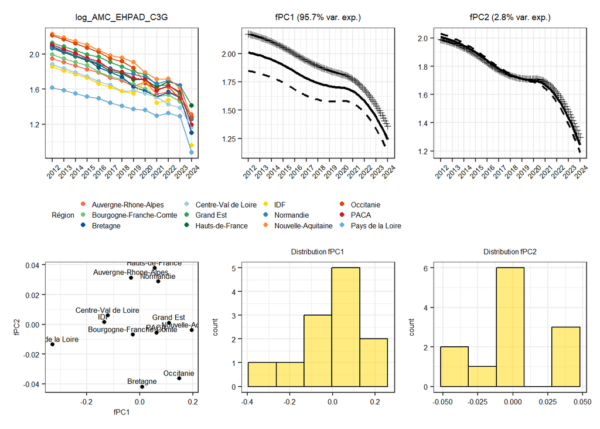

```r
cols <- c("IDF" = "#FFD700",
          "Auvergne-Rhone-Alpes" = "#FB6A4A", "PACA" = "#CB181D",
          "Nouvelle-Aquitaine" = "#FD8D3C", "Occitanie" = "#D94701",
          "Centre-Val de Loire" = "#9ECAE1", "Pays de la Loire" = "#6BAED6",
          "Normandie" = "#3182BD", "Bretagne" = "#08519C",
          "Bourgogne-Franche-Comte" = "#74C476", "Grand Est" = "#31A354",
          "Hauts-de-France" = "#006D2C")

plot_fpca_gg <- function(pca_fd_obj, harm = 1, xlab = "Temps", title = NULL) {

  # Grille de temps
  t_grid <- seq(0, 1, length.out = 100)
  # Moyenne
  mean_vals <- fda::eval.fd(t_grid, pca_fd_obj$meanfd)
  # Fonction propre (harm-ième)
  harmfd   <- pca_fd_obj$harmonics[harm]
  harm_vals <- fda::eval.fd(t_grid, harmfd)
  # Variance expliquée
  varprop <- round(pca_fd_obj$varprop[harm] * 100, 1)
  # Amplitude de perturbation (comme plot.pca.fd)
  score_sd <- sqrt(pca_fd_obj$values[harm])

  df <- data.frame(
    t     = t_grid,
    mean  = mean_vals[, 1],
    plus  = mean_vals[, 1] + score_sd * harm_vals[, 1],
    minus = mean_vals[, 1] - score_sd * harm_vals[, 1]
  )

  if (is.null(title)) title <- paste0("fPC", harm, " (", varprop, "% var. exp.)")

  ggplot(df, aes(x = t)) +
    geom_line(aes(y = mean), color = "black", linewidth = 1) +
    geom_point(aes(y = plus), shape = 3, color = "black") +
    geom_line(aes(y = minus), color = "black", linewidth = 0.8, linetype = "dashed") +
    labs(title = title, x = xlab, y = "") +
    scale_x_continuous(
      breaks = seq(0, 1, length.out = 13),
      label = as.character(2012:2024)
      )+
    theme_bw()+
    theme(plot.title = element_text(hjust = 0.5, size = 7),
          axis.text.y = element_text(color = "black", size = 6),
          axis.title = element_blank(),
          axis.text.x = element_text(angle = 45, vjust = 0.6, colour = "black", size = 6))
}

plot_comp_func <- function(data, variable){
g1 <- dat %>%
  dplyr::select(region, annee, variable) %>%
  tidyr::pivot_longer(!c("region", "annee"), names_to = "Var",
                      values_to = "value") %>%
  ggplot(aes(x = annee, y = value, col = region))+
  geom_point()+
  geom_line(show.legend = FALSE)+
  theme_bw()+
  labs(color = "Région",
       title = variable)+
  scale_x_continuous(breaks = seq(2012, 2024, by = 1),
                     minor_breaks = seq(2012, 2024, by = 1))+
  theme(axis.text.y = element_text(size = 6, color = "black"),
        axis.title = element_blank(),
        plot.title = element_text(hjust = 0.5, size = 7),
        axis.text.x = element_text(angle = 45, vjust = 0.6, colour = "black", size = 6),
        legend.text = element_text(size = 6),
        legend.title = element_text(size = 6),
        legend.position = "bottom",
        legend.justification = "left",
        legend.spacing = unit(0.5, "cm"),
        legend.key.height = unit(0.1, "cm"),
        legend.key.width = unit(0.1, "cm"),
        legend.key.spacing.y = unit(0.1, "cm")
        )+
  scale_color_manual(values = cols)


# Utilisation
p1 <- plot_fpca_gg(data[[2]][[variable]], harm = 1, xlab = "Temps")
p2 <- plot_fpca_gg(data[[2]][[variable]], harm = 2, xlab = "Temps")


p3 <- data[[1]] %>%
  ggplot(aes(x = .data[[paste0(variable,"_fPC1")]],
             y = .data[[paste0(variable,"_fPC2")]]))+
  geom_text(aes(label = rownames(data[[1]])), size = 2.3, vjust = -0.5)+
   geom_point(size = 1.3)+
  theme_bw()+
  labs(x = "fPC1", y = "fPC2")+
  theme(axis.text = element_text(color = "black", size = 6),
        axis.title = element_text(size = 6))

p4 <- data[[1]] %>%
  ggplot(aes(x = .data[[paste0(variable,"_fPC1")]]))+
  geom_histogram(bins = 5, fill = "gold", color = "black", alpha = .5)+
  theme_bw()+
  labs(title = "Distribution fPC1")+
  theme(axis.text = element_text(color = "black", size = 6),
        axis.title.x = element_blank(),
        plot.title = element_text(hjust = 0.5, size = 6),
        axis.title.y = element_text(size = 6))

p5 <- data[[1]] %>%
  ggplot(aes(x = .data[[paste0(variable,"_fPC2")]]))+
  geom_histogram(bins = 5, fill = "gold", color = "black", alpha = .5)+
  theme_bw()+
  labs(title = "Distribution fPC2")+
  theme(axis.text = element_text(color = "black", size = 6),
        axis.title.x = element_blank(),
        plot.title = element_text(hjust = 0.5, size = 6),
        axis.title.y = element_text(size = 6))


combined <- g1 + p1 + p2 + p3 + p4 + p5
return(combined)
}

plot_comp_func(data = dat.func_EHPAD_C3G, variable = "log_AMC_EHPAD_C3G")
```

### 2.1.2 log_AMC_EHPAD_FQ

- fPC1: diff moyenne, le PACA consomme beaucoup de FQ, IDF, bretagne et pays de la loire et centre val de loire consomment peu tout le temps
- fPC2: sont bien classées les régions qui consomment de plus en plus de FQ en EHPAD à partir du covid (Hauts-de-France, Bourgogne-Franche-Comté, Auvergne-Rhône-Alpes).
- fPC1 est symétriquement distribuée, fPC2 semble left skewed.

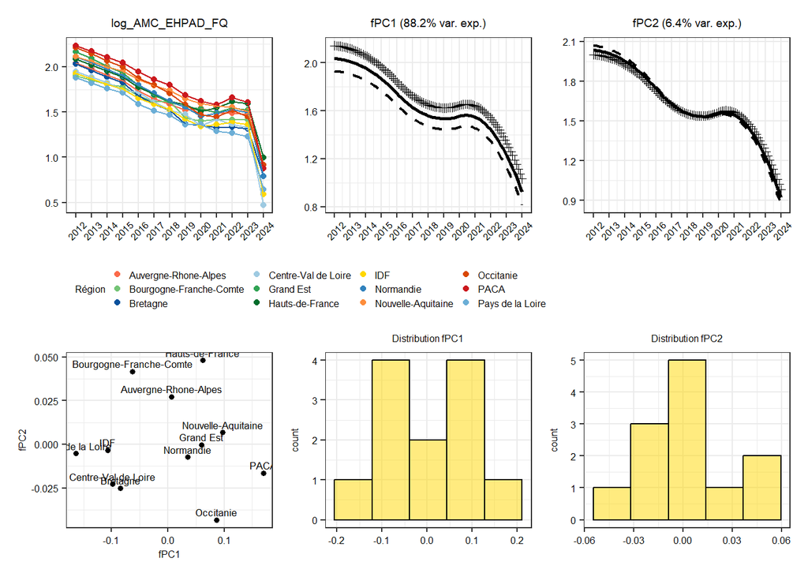

```r
g <- plot_comp_func(data = dat.func_EHPAD_FQ, variable = "log_AMC_EHPAD_FQ")
g
```

```r
# p_top3 <- g[[1]] + g[[2]] + g[[3]] + g[[4]]
#
# ggsave(
#   filename = "C:/Users/g.martet/Documents/functional_study/figures diapo/exemple_fPCA.png",
#   plot = p_top3,
#   width = 10,
#   height = 5,
#   dpi = 400
# )
```

### 2.1.3 log_AMC_ES_FQ

- fPC1: différence moyenne entre les régions: le grand est consomme beaucoup de fluoroquinolone en établissement de santé VS le bretagne qui en consomme peu
- fPC2: différence entre régions qui consomment plus après 2019 (IDF, pays de la Loire mal classés) VS régions qui consomment moins (Occitanie bien classée).

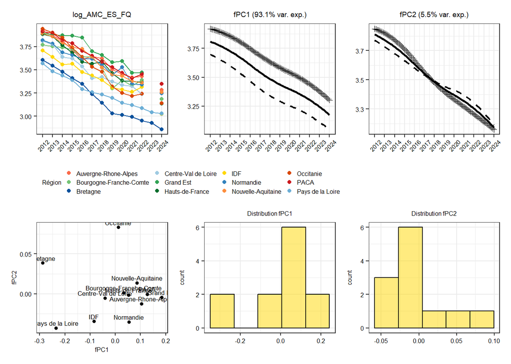

```r
plot_comp_func(data = dat.func_EHPAD_FQ, variable = "log_AMC_ES_FQ")
```

### 2.1.4 log_AMC_ES_C3G

- fPC1: différences régions qui consomment beaucoup (grand Est) à celles qui consomment peu (Pays de la Loire)
- fPC2: les régions bien classées sont celles qui stagnent en 2019 et qui remontent ensuite (Bourgogne Franche Comté)
- fPC1 est symmétriquement distribuée, et fPC2 semble right skewed

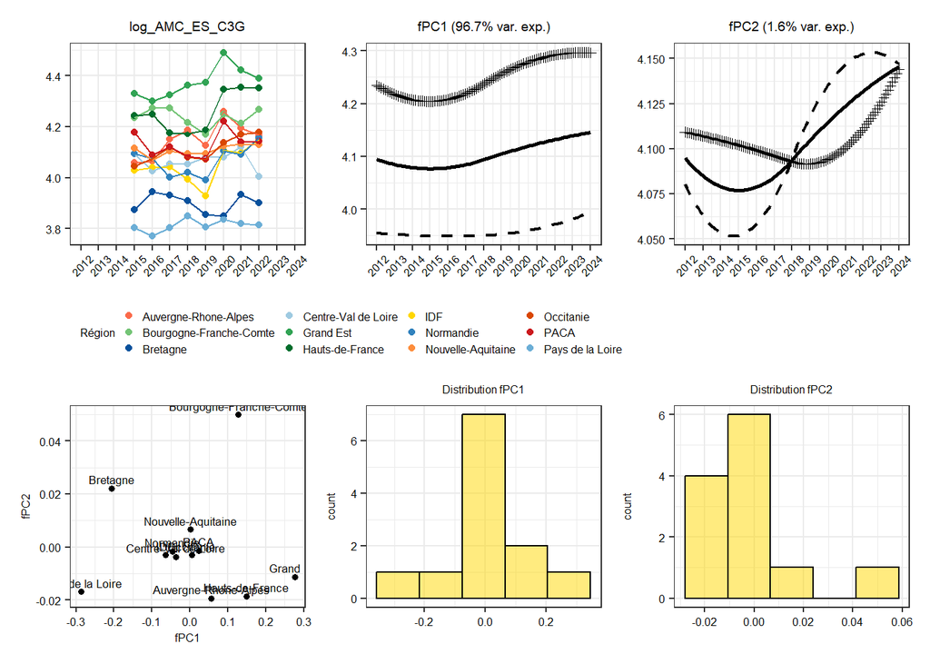

```r
plot_comp_func(data = dat.func_ES_C3G, variable = "log_AMC_ES_C3G")
```

### 2.1.5 log_AMC_ES_totale

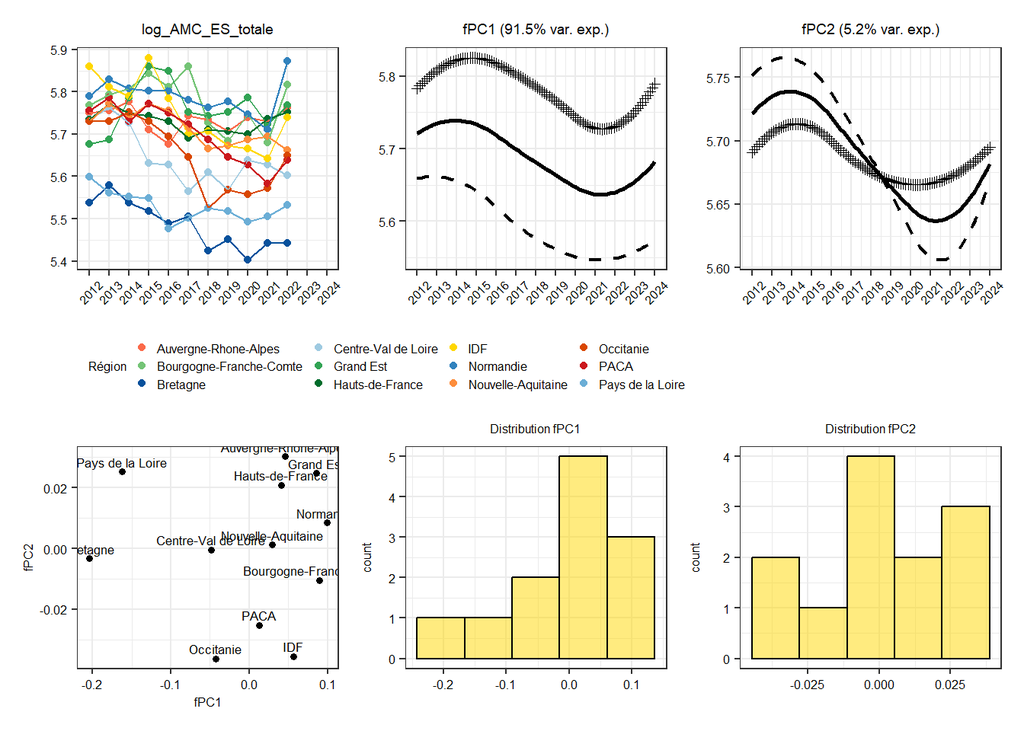

```r
plot_comp_func(data = dat.func_EHPAD_FQ, variable = "log_AMC_ES_totale")
```

### 2.1.6 log_AMC_ville_C3G

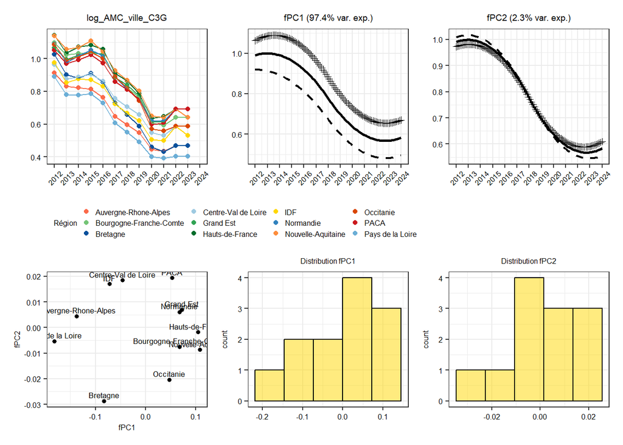

```r
plot_comp_func(data = dat.func_ES_C3G, variable = "log_AMC_ville_C3G")
```

### 2.1.7 log_AMC_ville_FQ

- fPC1 oppose les régions du sud qui consomment beaucoup aux régions de l’ouest.
- la fPC2 est difficilement intérprétable du fait qu’il n’y pas beaucoup de variation entre les régions. elle ne représente que 0,7% de la variance.

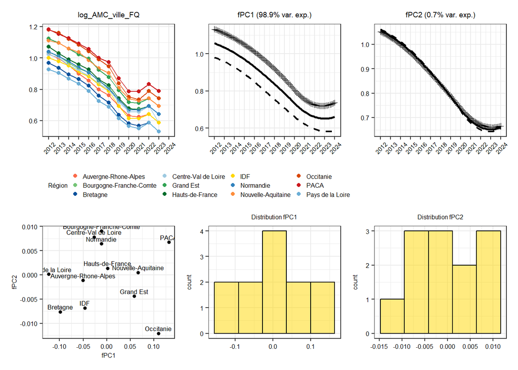

```r
plot_comp_func(data = dat.func_ville_FQ, variable = "log_AMC_ville_FQ")
```

### 2.1.8 log_AMC_ville_totale

- fPC1 oppose le PACA qui consomme beaucoup en ville aux pays de la Loire
- fPC2 semble être l’augmentation de consommation en période post-covid.
- fPC1 est left-skewed et fPC2 est right-skewed.

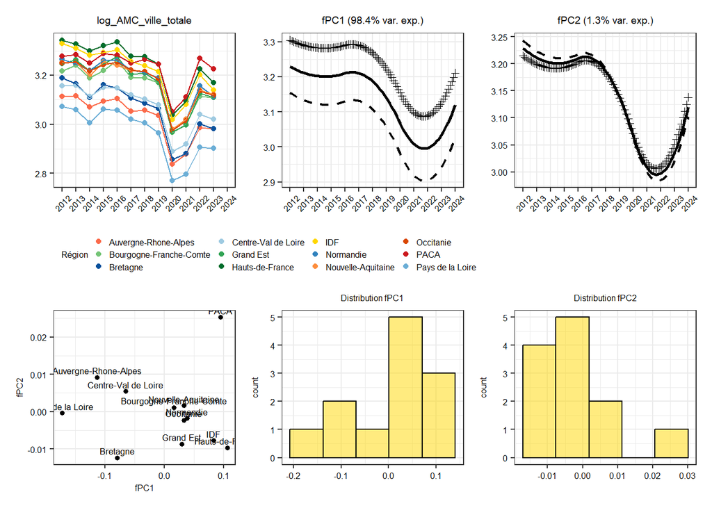

```r
plot_comp_func(data = dat.func_ville_FQ, variable = "log_AMC_ville_totale")
```

## 2.2 Animals

### 2.2.1 AMR_Animaux_compagnie_C3G

- Les trajectoires sont plus compliquées ici. Ce qui implique une baisse de % de variance exprimée par fPC1 et plus de variance expliquée par fPC2 que ce qu’on a pu voir auparavant. -fPC1: Les régions qui sont bien classées sont celles qui ont beaucoup de résistances aux C3G chez les animaux de compagnie sur une période de 2-3 ans (PACA 2018-2020, IDF 2012-2014, Pays de la Loire 2014-2015).
- fPC2: Les régions qui ont connu une recrudescense en résistance aux C3G chez les animaux de compagnie après 2016 sont bien classées selon fPC2 (PACA à partir de 2018, Normandie à partir de 2017), celles qui ont eu beaucoup de résistance aux début mais pour qui ça a baissé au cours du temps sont mal classées (IDF, Pays de la Loire).
- fPC1 semble avoir plus ou moins une distribution uniforme, fPC2 est right skewed.

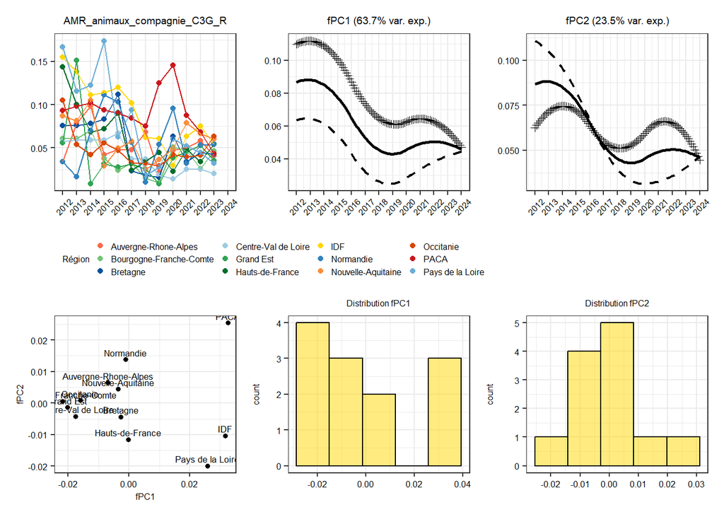

```r
plot_comp_func(data = dat.func_ES_FQ, variable = "AMR_animaux_compagnie_C3G_R")
```

### 2.2.2 AMR_Animaux_compagnie_FQ

-fPC1: Beaucoup de résistance en PACA et en IDF, peu de résistance en Centre Val de Loire et en Bourgogne Franche Comté de manière générale -fPC2: les régions qui ont connu une augmentation de la résistance aux FQ après 2014 (IDF, PACA, BFC) VS celles qui ont connu une diminution après 2014 (Pays de la Loire, Occitanie).

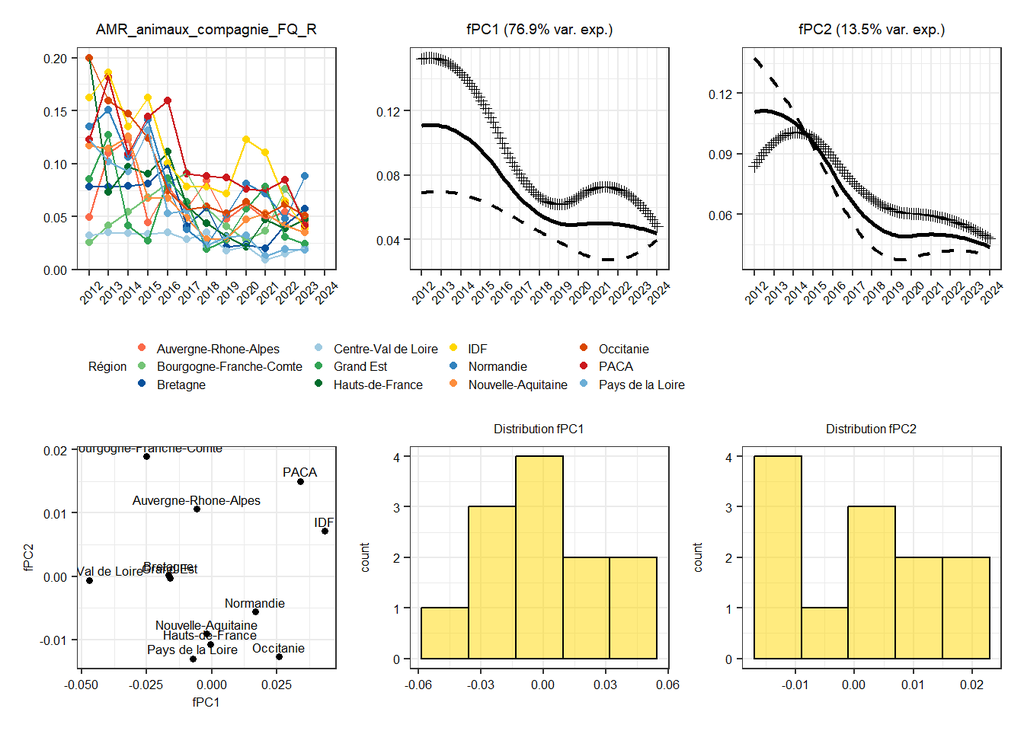

```r
plot_comp_func(data = dat.func_ville_FQ, variable = "AMR_animaux_compagnie_FQ_R")
```

### 2.2.3 AMR_Animaux_compagnie_amoxi_clav

-fPC1: les régions qui connaissent une augmentation plus marquée de la résistance après 2018 sont bien classées (Nouvelle-Aquitaine, Auvergne-Rhone-Alpes) VS celle qui la connaissent peu (Bretagne, Centre Val de Loire) -fPC2: différence de moyennes (Normandie et Hauts-de-France VS Bretagne).

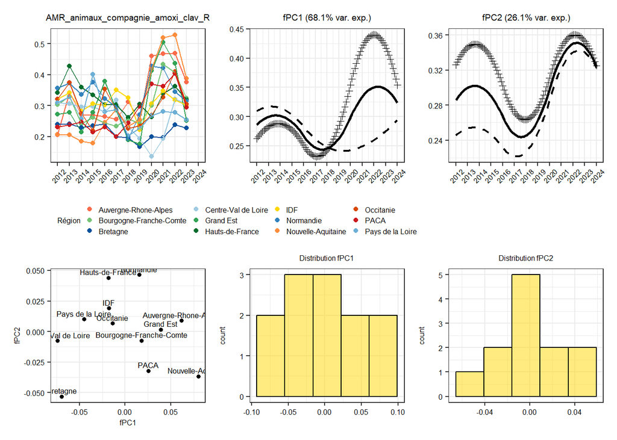

```r
plot_comp_func(data = dat.func_ville_C3G,
               variable = "AMR_animaux_compagnie_amoxi_clav_R")
```

### 2.2.4 AMR_Animaux_production_C3G

-fPC1: les régions qui connaissent beaucoup de resistance aux C3G chez les animaux de production avant 2017 sont bien classées (Centre Val de Loire, Occitanie, Grand Est) -fPC2: régions qui connaissent un/des Pics après 2017 (les Hauts-de-France).

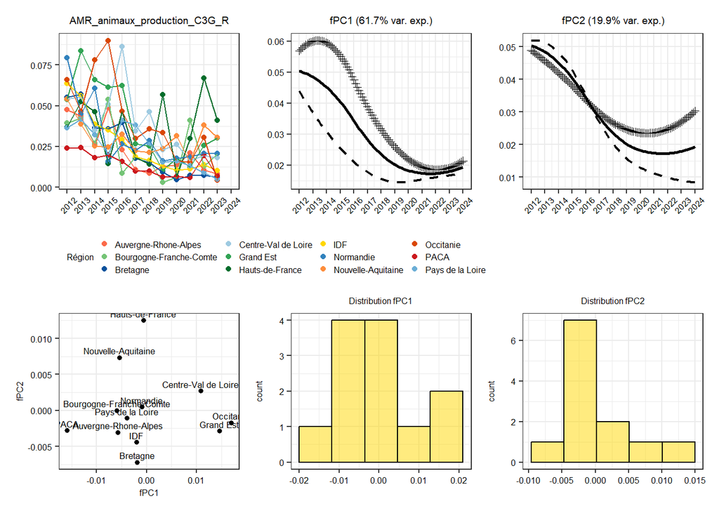

```r
plot_comp_func(data = dat.func_EHPAD_FQ, variable = "AMR_animaux_production_C3G_R")
```

### 2.2.5 AMR_Animaux_production_FQ

-fPC1: L’Occitanie a connu beaucoup de resistance aux FQ chez les animaux de production au début ce qui la classe devant toutes les autres régions. -fPC2: régions qui ont connu une petite augmentation après 2014 (Bourgogne Franche-Comté, Centre Val de Loire) VS celles qui ont connu une petite dimniution (Normandie, PACA). - fPC1 très right skewed et fpc2 symmétriquement distribuée

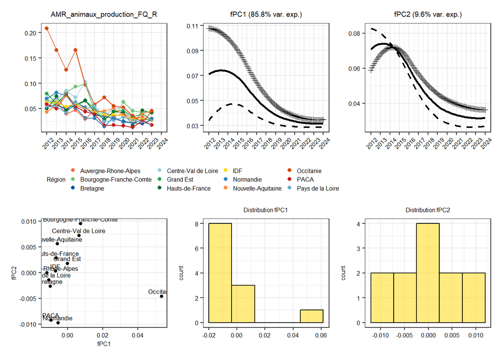

```r
plot_comp_func(data = dat.func_EHPAD_FQ, variable = "AMR_animaux_production_FQ_R")
```

### 2.2.6 veto_by_AC

- fPC1: différence moyenne globale: Bretagne, Auvergne-Rhone-Alpes beaucoup de veto par animaux de compagnie VS Hauts-de-France et Centre-Val-de-Loire
- fPC2: plus difficile, je dirai les régions qui ont connu une stagnation de leur nombre de veto après 2017.
- fPC1 est left skewed et fPC2 est uniformément distribué.

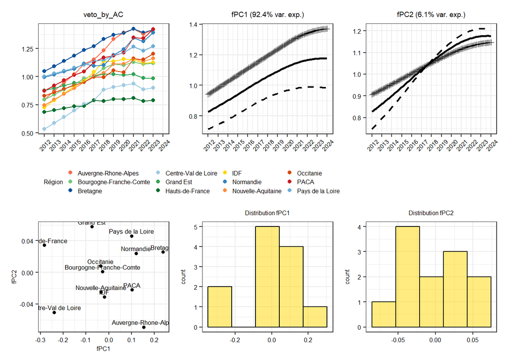

```r
plot_comp_func(data = dat.func_EHPAD_FQ, variable = "veto_by_AC")
```

### 2.2.7 veto_by_CV

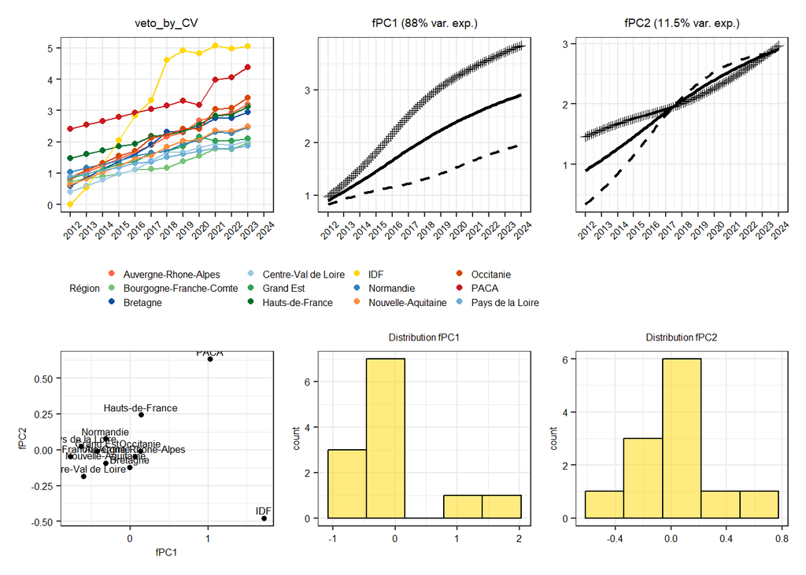

```r
plot_comp_func(data = dat.func_ville_C3G, variable = "veto_by_CV")
```

### 2.2.8 taux de possession de chats

- fPC1: régions qui ont beaucoup de chats tout le temps (Centre val de Loire, Nouvelle-Aquitaine, PACA) VS celles qui en ont moins (IDF, Auvergne-Rhone-Alpes).
- fPC2 concerne surtout IDF et PACA: stagnation du taux de possession de chats au cours du temps: l’IDF est le meilleur exemple, 3ème région avec le plus de chats en 2012, dernière en 2024, le PACA commence premier et finit 4ème.
- fPC1 légèrement right skewed et fPC2 très right skewed

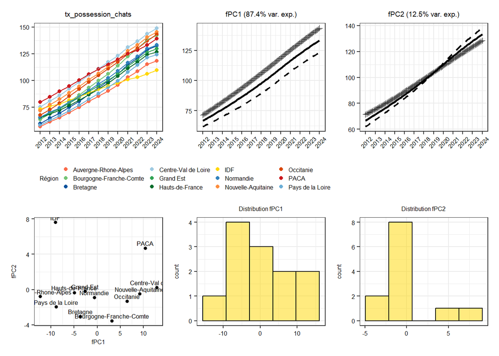

```r
plot_comp_func(data = dat.func_EHPAD_FQ, variable = "tx_possession_chats")
```

### 2.2.9 taux de possession de chevaux

- le fPC1 résume casiment tout car il y a beaucoup de variabilité régionale mais peu de variabilité temporelle pour cette variable. Normandie VS IDF

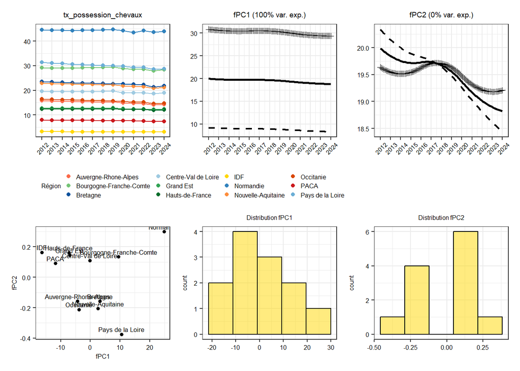

```r
plot_comp_func(data = dat.func_EHPAD_C3G, variable = "tx_possession_chevaux")
```

### 2.2.10 log_UGB_density_livestock_tot

- le fPC1 résume casiment tout car il y a beaucoup de variabilité régionale mais peu de variabilité temporelle pour cette variable. régions rurales (Bretagne, Pays de la Loire) VS régions urbaines (PACA, IDF).

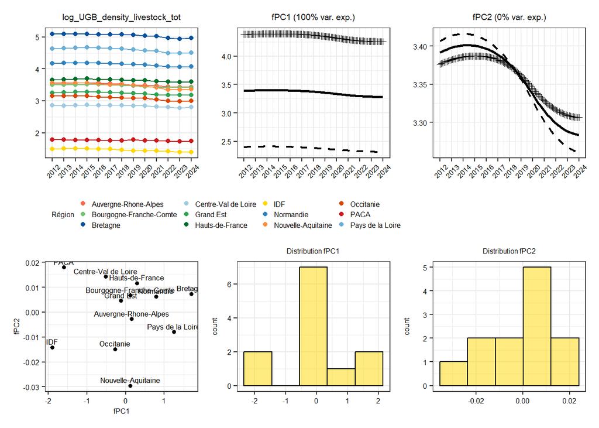

```r
plot_comp_func(data = dat.func_EHPAD_FQ, variable = "log_UGB_density_livestock_tot")
```

### 2.2.11 log_UGB_density_volailles

- le fPC1 résume casiment tout car il y a beaucoup de variabilité régionale mais peu de variabilité temporelle pour cette variable. régions rurales (Bretagne, Pays de la Loire) VS régions urbaines (PACA, IDF).

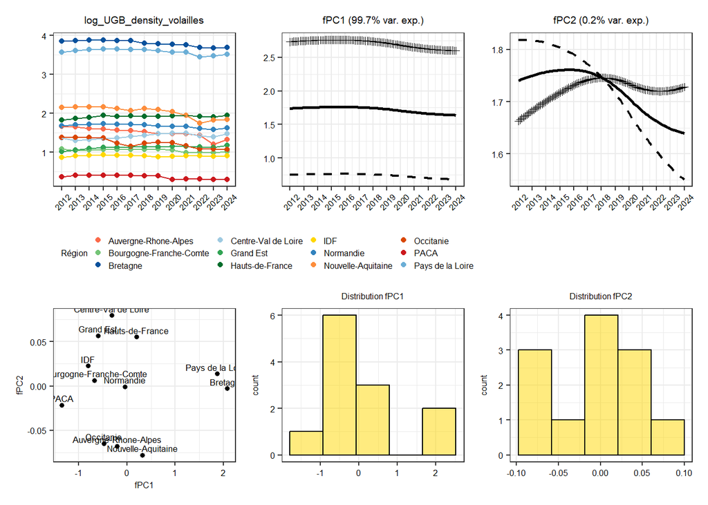

```r
plot_comp_func(data = dat.func_EHPAD_C3G, variable = "log_UGB_density_volailles")
```

## 2.3 Environnement

### 2.3.1 air_PM25_pop

- fPC1: différence de moyennes, régions avec beaucoup de particules fines (IDF, Hauts-de-France, PACA) VS celles où il y en a moins: Bretagne, Nouvelle-Aquitaine, Occitanie
- fPC2: le fait d’avoir connu une augmentation de particules fines après 2018.

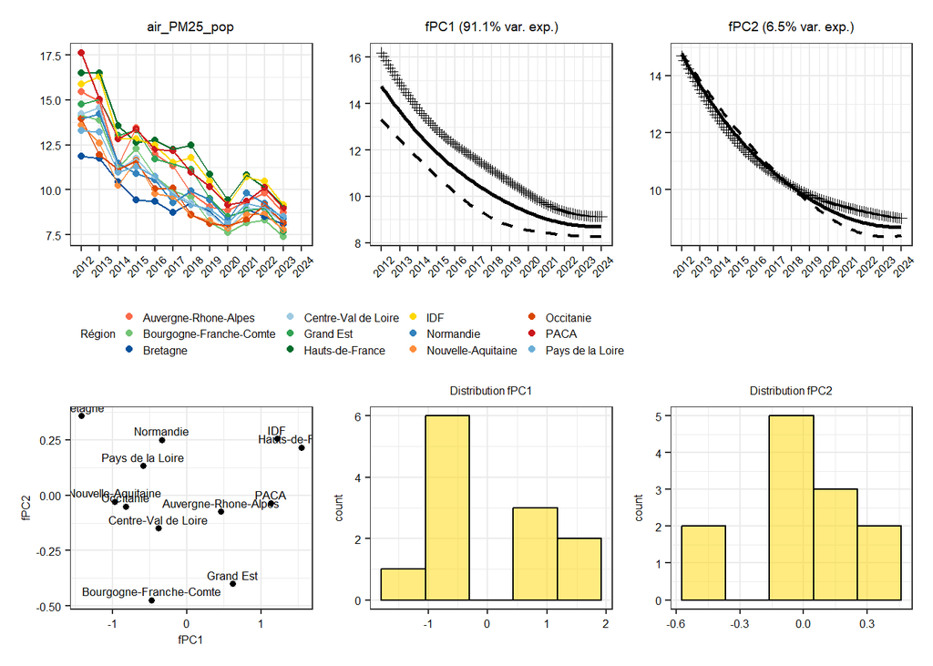

```r
plot_comp_func(data = dat.func_EHPAD_C3G, variable = "air_PM25_pop")
```

### 2.3.2 dju_refroi

- fPC1: sans surprise, les régions du sud sont bien classées selon cet axe car il fait plus chaud l’été là-bas donc ils utilisent plus la clim qu’en Bretagne ou en Normandie.
- fPC2: l’augmentation de l’usage de la clim après 2021, il y a un creux en 2021 (du à l’absence de canicule).

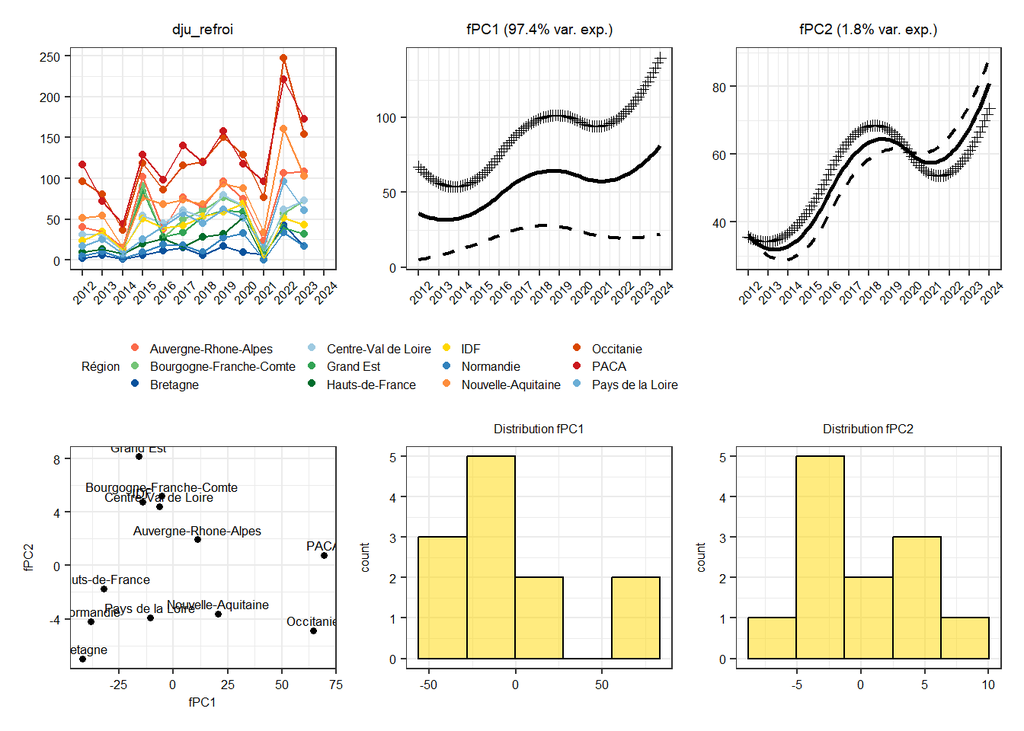

```r
plot_comp_func(data = dat.func_EHPAD_C3G, variable = "dju_refroi")
```

## 2.4 Humans

### 2.4.1 EQI

- fPC1: diff moyenne, la Bretagne a un EQI élevé tout le temps VS le PACA et l’IDF
- fPC2: c’est surtout lIDF qui connait une grosse baisse de l’EQI à partir de 2017 et qui est mal classé selon cet axe, a contrario, au centre Val de Loire, ça ne fait qu’augmenter.
- fPC1 est right skewed et fPC2 est left skewed.

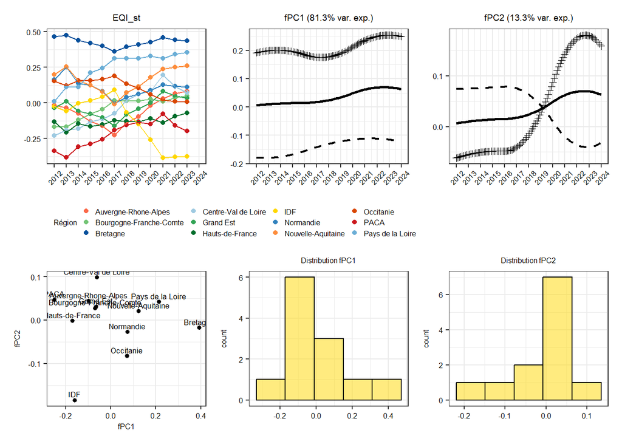

```r
plot_comp_func(data = dat.func_ES_FQ, variable = "EQI_st")
```

### 2.4.2 tx_pauvrete_60

Cette variable signifie que le seuil de pauvreté est fixé à 60 % du niveau de vie médian de France métropolitaine.

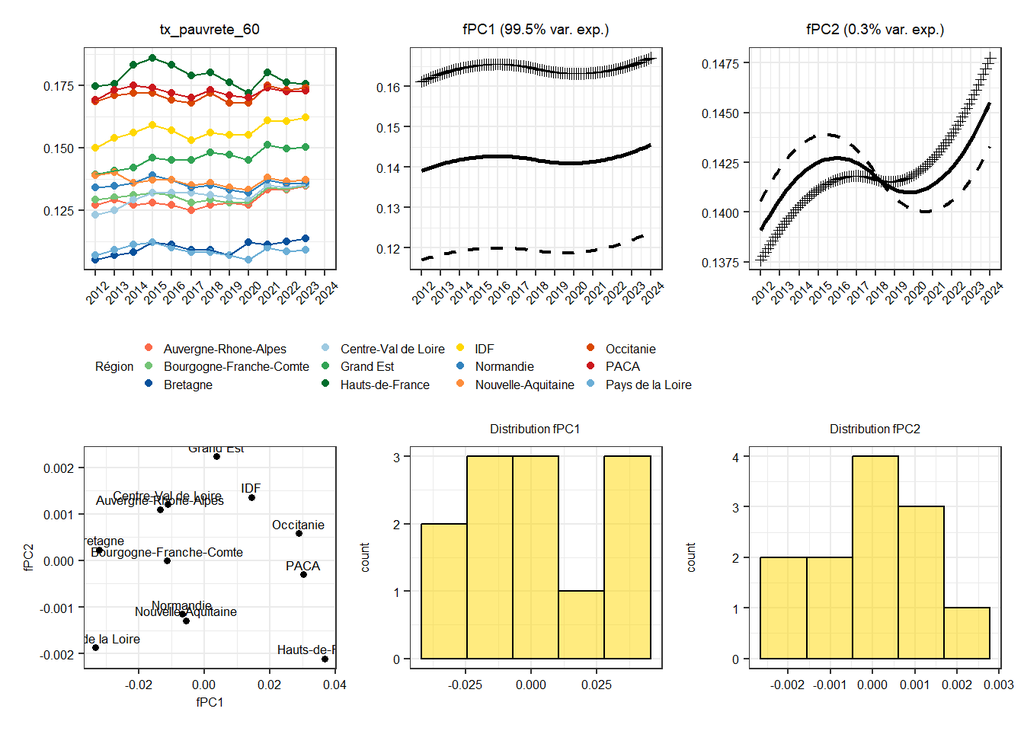

```r
plot_comp_func(data = dat.func_ES_C3G, variable = "tx_pauvrete_60")
```

### 2.4.3 médecin par habitants

- fPC1: PACA et IDF bien classés avec beaucoup de médecins par habitants VS Centre-Val-de-Loire.
- fPC2: les régions bien classées sont celles qui connaissent une augmentation du nombre de médecin par habitants (exemple Bretagne) VS celles qui connaissent une stagnation (ex: IDF).
- fPC1 right skewed et fPC2 bien symmétriquement distribué.

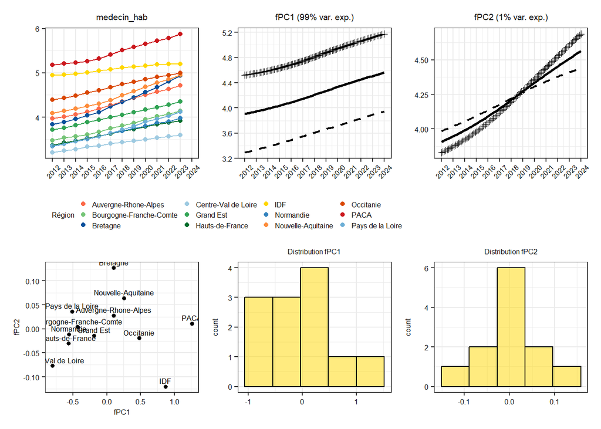

```r
plot_comp_func(data = dat.func_ES_C3G, variable = "medecin_hab")
```

### 2.4.4 pop_75_plus_prop

-fPC1: régions avec population assez vieille (ex: PACA et Nouvelle-Aquitaine) VS régions avec population plus jeune (IDF, Hauts-de-France). - fPC2: très peu de variance expliquée, elle se caractérise surtout par le vieillissement de la population d’une région après 2018 et concerne surtout le PACA.

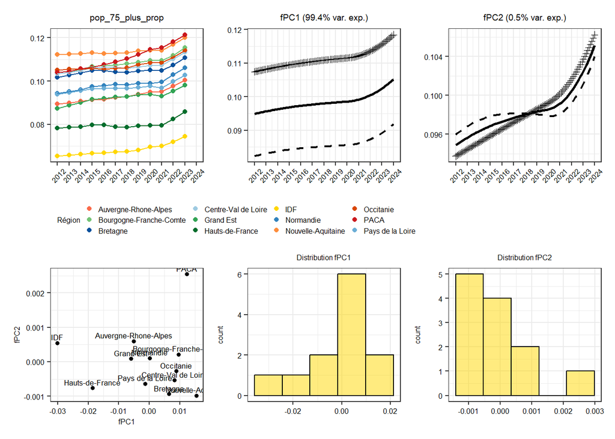

```r
plot_comp_func(data = dat.func_EHPAD_FQ, variable = "pop_75_plus_prop")
```

# 3 Comparaison des régression GSCA

Le but ici, contrairement au Rmarkdown précédant, va être de considérer un modèle GSCA avec tous les blocs qui expliquent le block Y indépendamment, mais les blocks explicatifs ne s’expliquent pas entre eux.

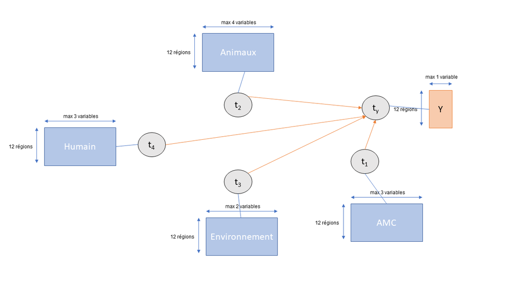

Nous allons également comparer ce modèle avec le modèle complet déjà effectué dans le Rmarkdown précédent et voir si les coefficients restent stables:

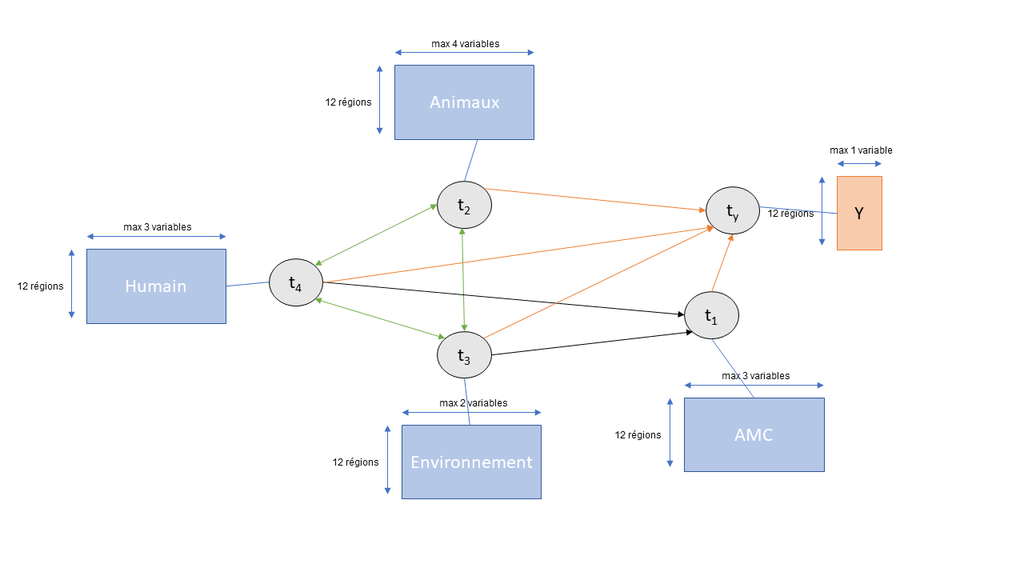

En fonction de ce modèle complet, nous créerons un modèle intermédiaire avec moins de sous-modèle en supprimant les paths coeffs proches de 0. Nous en étudierons la stabilité et nous allons comparer les trois modèles

## 3.1 AMR ville FQ

### 3.1.1 Unidimensionalité des blocks

Le block AMC est unidimensionnel. Les blocks Environnement et Humains sont acceptables. Le block Animals ne semble pas unidimensionnel, cela peut-être du aux 4 variables dans le block au lieu de 2 pour les autres.

```r
source("C:/Users/g.martet/Documents/functional_study/explo_gesca.R")

dfPC1.AMR_ville_FQ <- scale(dfPC1.AMR_ville_FQ) # standardisation

# Hypothèse d'unidimensionalité des blocks
Xnorm.block <- list(dfPC1.AMR_ville_FQ[,which(colnames(dfPC1.AMR_ville_FQ) %in% c("log_AMC_ville_FQ", "log_AMC_ville_tot_except_FQ"))],
                    dfPC1.AMR_ville_FQ[,which(colnames(dfPC1.AMR_ville_FQ) %in% c("AMR_animaux_compagnie_FQ_R", "AMR_animaux_production_FQ_R", "tx_possession_chats", "log_UGB_density_livestock_tot"))],
                    dfPC1.AMR_ville_FQ[,which(colnames(dfPC1.AMR_ville_FQ) %in% c("air_PM25_pop", "dju_refroi"))],
                    dfPC1.AMR_ville_FQ[,which(colnames(dfPC1.AMR_ville_FQ) %in% c("medecin_hab", "unemployement_pourc"))]
                    )

nb.block <- length(Xnorm.block)
order_blocks <- c("AMC", "Animals", "Environment", "Humans")
eigen <- lapply(1:nb.block, function(k) FactoMineR::PCA(Xnorm.block[[k]], scale.unit = TRUE, ncp = 2, graph = F)$eig)
perc_var_comp1 <- c()
for(i in 1:nb.block){
  perc_var_comp1 <- c(perc_var_comp1, eigen[[i]][1,2])
}
df.unim <- data.frame(order_blocks,
                      percentage_variance_PCA_comp1 = round(perc_var_comp1, 2))
knitr::kable(df.unim)
```

| order_blocks | percentage_variance_PCA_comp1 |
| --- | --- |
| AMC | 81.89 |
| Animals | 41.53 |
| Environment | 52.24 |
| Humans | 53.81 |

### 3.1.2 Paths coeffs

Les paths coeffs ont l’air de varier assez peu entre le modèle complet et le modèle intermédiaire.

En regardant le tableau, le modèle simple semble surestimer un peu le lien entre Y et AMC, Environnement par rapport au modèle complet et sous-estimer celui entre Y et Animals. Etonnament le modèle simple semble plus proche du modèle complet pour le lien entre Y et Humains que le modèle intermédiaire qui sous-estime un peu ce lien.

En regardant le graphique, les paths coeffs liés à Y semblent être estimés de manière plus précise avec le modèle intermédiaire.

**Conclusion:** Le modèle complet ne semble pas apporter beaucoup plus d’information que le modèle intermédiaire. Le modèle intermédiaire est meilleur dans l’estimation des paths coeffs liés à Y.

```r
model_simple <- paste(
  paste("Y =~", colnames(dfPC1.AMR_ville_FQ)[1]),
  "AMC =~ log_AMC_ES_FQ + log_AMC_ville_FQ",
  "Animals =~ AMR_animaux_compagnie_FQ_R + AMR_animaux_production_FQ_R + veto_by_AC + log_UGB_density_livestock_tot",
  "Environment =~ dju_refroi + air_PM25_pop",
  "Humans =~ medecin_hab + EQI_st",
  "Y ~ AMC + Animals + Environment + Humans",
  sep = "\n\t\t"
)

model_complet <- paste(
  paste("Y =~", colnames(dfPC1.AMR_ville_FQ)[1]),
  "AMC =~ log_AMC_ES_FQ + log_AMC_ville_FQ",
  "Animals =~ AMR_animaux_compagnie_FQ_R + AMR_animaux_production_FQ_R + veto_by_AC + log_UGB_density_livestock_tot",
  "Environment =~ dju_refroi + air_PM25_pop",
  "Humans =~ medecin_hab + EQI_st",
  "Y ~ AMC + Animals + Environment + Humans",
  "AMC ~ Humans + Environment",
  "Environment ~ Animals + Humans",
  "Humans ~ Environment + Animals",
  "Animals ~ Environment + Humans",
  sep = "\n\t\t"
)

model_int <- paste(
  paste("Y =~", colnames(dfPC1.AMR_ville_FQ)[1]),
  "AMC =~ log_AMC_ES_FQ + log_AMC_ville_FQ",
  "Animals =~ AMR_animaux_compagnie_FQ_R + AMR_animaux_production_FQ_R + veto_by_AC + log_UGB_density_livestock_tot",
  "Environment =~ dju_refroi + air_PM25_pop",
  "Humans =~ medecin_hab + EQI_st",
  "Y ~ AMC + Humans",
  "AMC ~ Humans + Environment",
  "Environment ~ Animals + Humans",
  "Humans ~ Environment + Animals",
  "Animals ~ Environment + Humans",
  sep = "\n\t\t"
)

set.seed(123)
mod_complet <- gesca::gesca.run(model_complet, dfPC1.AMR_ville_FQ, nbt = 100)
sum_gsca_complet <- summary_gesca2(mod_complet)
mod_simple <- gesca::gesca.run(model_simple, dfPC1.AMR_ville_FQ, nbt = 100)
sum_gsca_simple <- summary_gesca2(mod_simple)
mod_int <- gesca::gesca.run(model_int, dfPC1.AMR_ville_FQ, nbt = 100)
sum_gsca_int <- summary_gesca2(mod_int)

paths_complet <- sum_gsca_complet$paths
paths_complet$model <- rep("complet", nrow(paths_complet))
paths_simple <- sum_gsca_simple$paths
paths_simple$model <- rep("simple", nrow(paths_simple))
paths_int <- sum_gsca_int$paths
paths_int$model <- rep("int", nrow(paths_int))
paths <- rbind.data.frame(paths_complet, paths_simple, paths_int)

DT::datatable(paths)
```

|  | group | term | estimate | std.error | ci_lb | ci_ub | model |
| --- | --- | --- | --- | --- | --- | --- | --- |
| 1 | all | Y~AMC | 0.119 | 3.1392 | -2.9942 | 3.9438 | complet |
| 2 | all | Y~Animals | -0.0352 | 19.3641 | -45.0351 | 42.2448 | complet |
| 3 | all | Environment~Animals | -0.4021 | 1.3012 | -2.2554 | 3.304 | complet |
| 4 | all | Humans~Animals | 0.5848 | 0.7335 | -1.4973 | 1.0966 | complet |
| 5 | all | Y~Environment | -0.018 | 9.0121 | -14.6411 | 25.741 | complet |
| 6 | all | AMC~Environment | 0.7983 | 1.1193 | -2.0636 | 2.4799 | complet |
| 7 | all | Animals~Environment | -0.2816 | 1.0233 | -1.8489 | 2.589 | complet |
| 8 | all | Humans~Environment | 0.4408 | 0.6241 | -1.0584 | 1.6301 | complet |
| 9 | all | Y~Humans | 0.8933 | 14.9889 | -36.4193 | 36.4574 | complet |
| 10 | all | AMC~Humans | -0.1263 | 1.1098 | -1.8358 | 2.7415 | complet |

[output cut: 16 more lines]

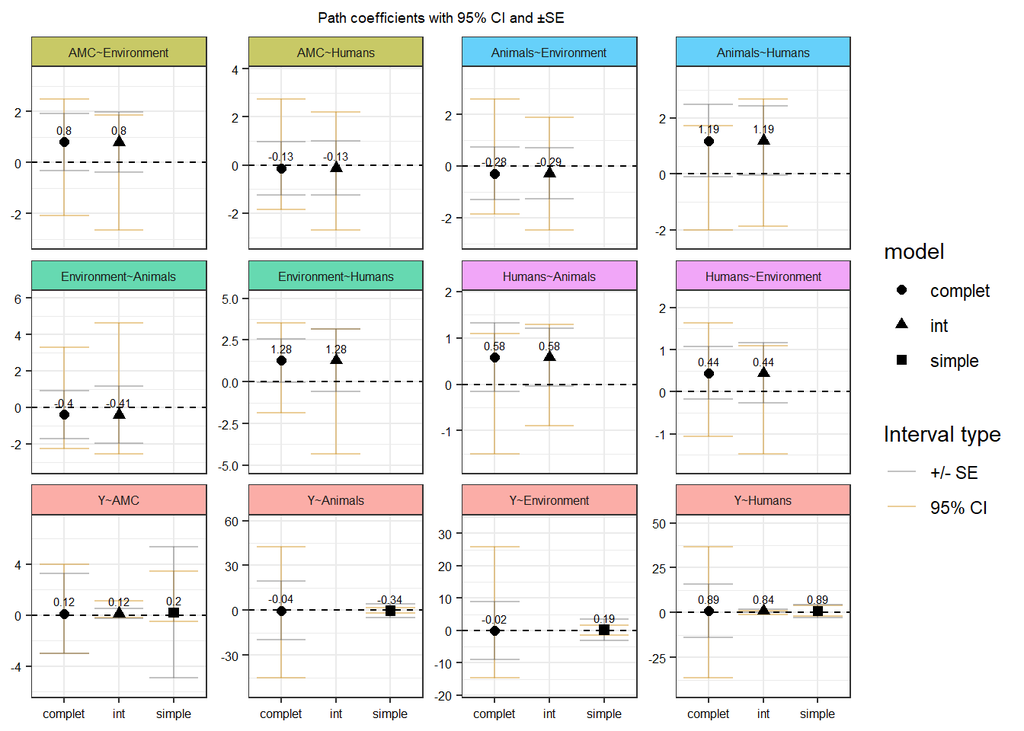

```r
# 1. extraire la variable à expliquer (à gauche du ~)
paths$outcome <- str_remove(paths$term, "~.*")

# 2. créer une palette nommée par variable à expliquer
outcomes <- unique(paths$outcome)
pal <- setNames(c("#F8766D", "#00BF7D", "#E76BF3",
                  "#A3A500", "#00B0F6"), outcomes)

# 3. vecteur de couleurs DANS L'ORDRE DES FACETTES
# (l'ordre des term tel qu'il apparaîtra dans facet_wrap, généralement alphabétique
# sauf si term est déjà un factor avec un ordre précis)
term_outcome_map <- setNames(paths$outcome, paths$term)
term_levels <- sort(unique(paths$term))
# applique 0.6 d'opacité à chaque couleur de la palette
pal_alpha <- scales::alpha(pal, 0.6)
strip_colors <- pal_alpha[term_outcome_map[term_levels]]


ggplot(paths, aes(x = model, y = estimate)) +
    geom_errorbar(aes(ymin = ci_lb, ymax = ci_ub, color = "95% CI"),
                   height = 0.1, alpha = 0.4) +
    geom_errorbar(aes(ymin = estimate - std.error,
                       ymax = estimate + std.error,
                       color = "+/- SE"),
                   height = 0.1, linewidth = 0.4, alpha = 0.4) +
    geom_point(aes(shape = model), size = 2) +
    geom_text(aes(label = round(estimate, 2)), size = 2,
              vjust = -0.86)+
    geom_hline(yintercept = 0, linetype = "dashed") +
    ggh4x::facet_wrap2(~ term, scales = "free_y",
                       strip = strip_themed(
      background_x = elem_list_rect(fill = strip_colors)
    ))+
    theme_bw() +
  scale_y_continuous(expand = expansion(mult = c(0.15, 0.25))) +
    labs(title = "Path coefficients with 95% CI and ±SE")+
    theme(axis.text = element_text(color = "black", size = 6),
          axis.title = element_blank(),
          plot.title = element_text(hjust = 0.5, size = 7),
          strip.text = element_text(size = 6))+
  scale_color_manual(name = "Interval type",
                     values = c(
                       "95% CI" = "orange3",
                       "+/- SE" = "grey40"))
```

### 3.1.3 Loadings

Les loadings semblent assez stables entre les trois modèles. Pour les variable du block Animals, ceux du modèle simple dévient du modèle complet et/ou du modèle intermédiaire.

```r
var_to_test <- colnames(dat %>%
                          dplyr::select(-annee, -region, -AMR_EHPAD_C3G_R, -AMR_EHPAD_FQ_R,
                                        -AMR_EHPAD_amoxi_clav_R, -AMR_ville_C3G_R,   -AMR_ville_amoxi_clav_R, -AMR_ville_FQ_R, -AMR_ES_FQ_R, -AMR_ES_amoxi_clav_R, -AMR_ES_C3G_R, -log_AMR_ville_FQ_R))

correspondance_block <- data.frame(block = c(
rep("Animals", 6), rep("AMC", 24), rep("Humans",8),
rep("Animals", 3), rep("AMC", 4), "Humans", "Animals", rep("Humans", 6),
rep("Animals", 5), rep("Humans", 4), rep("Environment", 11),
rep("Animals", 13)),
term = var_to_test)


loadings_complet <- sum_gsca_complet$loadings
loadings_complet$model <- rep("complet", nrow(loadings_complet))
loadings_simple <- sum_gsca_simple$loadings
loadings_simple$model <- rep("simple", nrow(loadings_simple))
loadings_int <- sum_gsca_int$loadings
loadings_int$model <- rep("int", nrow(loadings_int))
loadings <- rbind.data.frame(loadings_complet, loadings_simple, loadings_int)

DT::datatable(loadings)
```

|  | group | term | estimate | std.error | ci_lb | ci_ub | model |
| --- | --- | --- | --- | --- | --- | --- | --- |
| 1 | all | AMR_ville_FQ_R | 1 | 0 | 1 | 1 | complet |
| 2 | all | log_AMC_ES_FQ | 0.9151 | 0.2035 | 0.6347 | 0.9935 | complet |
| 3 | all | log_AMC_ville_FQ | 0.9479 | 0.0465 | 0.8493 | 0.9984 | complet |
| 4 | all | AMR_animaux_compagnie_FQ_R | 0.7815 | 0.7073 | -0.9521 | 0.9571 | complet |
| 5 | all | AMR_animaux_production_FQ_R | 0.0513 | 0.5687 | -0.9651 | 0.9598 | complet |
| 6 | all | veto_by_AC | -0.0211 | 0.553 | -0.8582 | 0.9259 | complet |
| 7 | all | log_UGB_density_livestock_tot | -0.9162 | 0.7195 | -0.9816 | 0.9856 | complet |
| 8 | all | air_PM25_pop | 0.6851 | 0.6815 | -0.9498 | 0.9993 | complet |
| 9 | all | dju_refroi | 0.7584 | 0.5308 | -0.8814 | 0.971 | complet |
| 10 | all | EQI_st | -0.7679 | 0.6497 | -0.9976 | 0.9989 | complet |

[output cut: 23 more lines]

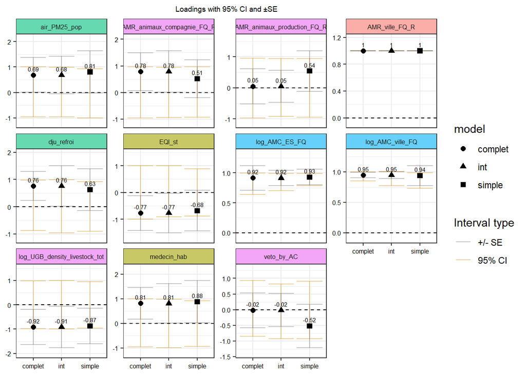

```r
loadings <- loadings %>% dplyr::left_join(correspondance_block,
                              by = "term")
loadings$block <- ifelse(is.na(loadings$block),
                         "Y", loadings$block)

blocks <- unique(loadings$block)
pal <- setNames(c("#F8766D", "#00B0F6", "#E76BF3",
                  "#00BF7D", "#A3A500"), blocks)
term_loadings_map <- setNames(loadings$block, loadings$term)
term_levels <- sort(unique(loadings$term))
# applique 0.6 d'opacité à chaque couleur de la palette
pal_alpha <- scales::alpha(pal, 0.6)
strip_colors <- pal_alpha[term_loadings_map[term_levels]]


ggplot(loadings, aes(x = model, y = estimate)) +
    geom_errorbar(aes(ymin = ci_lb, ymax = ci_ub, color = "95% CI"),
                   height = 0.1, alpha = 0.4) +
    geom_errorbar(aes(ymin = estimate - std.error,
                       ymax = estimate + std.error,
                       color = "+/- SE"),
                   height = 0.1, linewidth = 0.4, alpha = 0.4) +
  geom_text(aes(label = round(estimate, 2)), size = 2,
              vjust = -0.86)+
    geom_point(aes(shape = model), size = 2) +
    geom_hline(yintercept = 0, linetype = "dashed") +
    ggh4x::facet_wrap2(~ term, scales = "free_y",
                       strip = strip_themed(
      background_x = elem_list_rect(fill = strip_colors)
    ))+
    theme_bw() +
    labs(title = "Loadings with 95% CI and ±SE")+
    theme(axis.text = element_text(color = "black", size = 6),
          axis.title = element_blank(),
          plot.title = element_text(hjust = 0.5, size = 7),
          strip.text = element_text(size = 6))+
  scale_y_continuous(expand = expansion(mult = c(0.15, 0.25))) +
  scale_color_manual(name = "Interval type",
                     values = c(
                       "95% CI" = "orange3",
                       "+/- SE" = "grey40"))
```

### 3.1.4 Poids

les poids sont relativement stables entre le modèle complet et le modèle intermédiaire, les variables contribuent à peu près de la même manière aux variables latentes. Le modèle simple lui pour le coup donne un peu plus ou un peu moins d’importances à certaines variables dans leurs variables latentes.

```r
weights_complet <- sum_gsca_complet$weights
weights_complet$model <- rep("complet", nrow(weights_complet))
weights_simple <- sum_gsca_simple$weights
weights_simple$model <- rep("simple", nrow(weights_simple))
weights_int <- sum_gsca_int$weights
weights_int$model <- rep("int", nrow(weights_int))
weights <- rbind.data.frame(weights_complet, weights_simple, weights_int)

DT::datatable(weights)
```

|  | group | term | estimate | std.error | ci_lb | ci_ub | model |
| --- | --- | --- | --- | --- | --- | --- | --- |
| 1 | all | AMR_ville_FQ_R | 1 | 0 | 1 | 1 | complet |
| 2 | all | log_AMC_ES_FQ | 0.4729 | 0.1871 | 0.0869 | 0.7837 | complet |
| 3 | all | log_AMC_ville_FQ | 0.5985 | 0.1642 | 0.2483 | 0.9249 | complet |
| 4 | all | AMR_animaux_compagnie_FQ_R | 0.3687 | 0.3873 | -0.7323 | 0.7054 | complet |
| 5 | all | AMR_animaux_production_FQ_R | -0.0544 | 0.3778 | -0.84 | 0.7642 | complet |
| 6 | all | veto_by_AC | 0.1233 | 0.3065 | -0.5815 | 0.6472 | complet |
| 7 | all | log_UGB_density_livestock_tot | -0.7828 | 0.5925 | -0.9071 | 1.1572 | complet |
| 8 | all | air_PM25_pop | 0.6525 | 0.5667 | -0.9028 | 0.9959 | complet |
| 9 | all | dju_refroi | 0.7291 | 0.4539 | -0.8932 | 1.017 | complet |
| 10 | all | EQI_st | -0.5997 | 0.55 | -1 | 0.9962 | complet |

[output cut: 23 more lines]

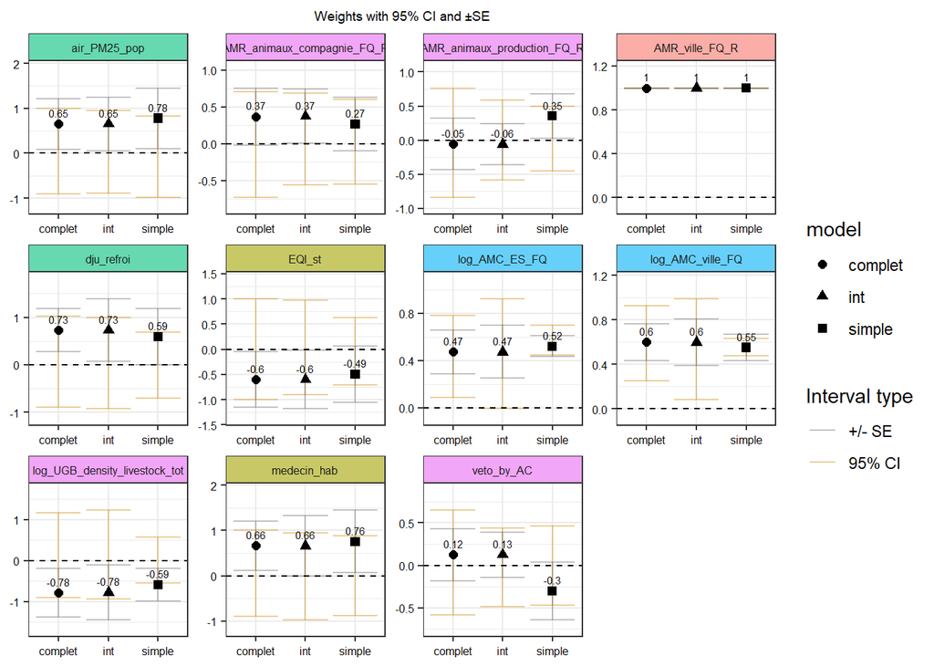

```r
weights <- weights %>% dplyr::left_join(correspondance_block,
                              by = "term")
weights$block <- ifelse(is.na(weights$block),
                         "Y", weights$block)

blocks <- unique(weights$block)
pal <- setNames(c("#F8766D", "#00B0F6", "#E76BF3",
                  "#00BF7D", "#A3A500"), blocks)
term_weights_map <- setNames(weights$block, weights$term)
term_levels <- sort(unique(weights$term))
# applique 0.6 d'opacité à chaque couleur de la palette
pal_alpha <- scales::alpha(pal, 0.6)
strip_colors <- pal_alpha[term_loadings_map[term_levels]]


ggplot(weights, aes(x = model, y = estimate)) +
    geom_errorbar(aes(ymin = ci_lb, ymax = ci_ub, color = "95% CI"),
                   height = 0.1, alpha = 0.4) +
    geom_errorbar(aes(ymin = estimate - std.error,
                       ymax = estimate + std.error,
                       color = "+/- SE"),
                   height = 0.1, linewidth = 0.4,  alpha = 0.4) +
    geom_point(aes(shape = model), size = 2) +
    geom_text(aes(label = round(estimate, 2)), size = 2, vjust = -0.86)+
    geom_hline(yintercept = 0, linetype = "dashed") +
    ggh4x::facet_wrap2(~ term, scales = "free",
                       strip = strip_themed(
      background_x = elem_list_rect(fill = strip_colors)))+
  scale_y_continuous(expand = expansion(mult = c(0.15, 0.25)))+
    theme_bw() +
    labs(title = "Weights with 95% CI and ±SE")+
    theme(axis.text = element_text(color = "black", size = 6),
          axis.title = element_blank(),
          plot.title = element_text(hjust = 0.5, size = 7),
          strip.text = element_text(size = 6))+
  scale_color_manual(name = "Interval type",
                     values = c(
                       "95% CI" = "orange3",
                       "+/- SE" = "grey40"))
```

### 3.1.5 R2

la qualité explicative des modèles complet et intermédiaire sont similaire. Le block Y est toutefois mieux expliqué avec le modèle simple.

```r
# corrélations entre composantes latentes
# complet
latentcorr_complet <- mod_complet$latentcorr
rownames(latentcorr_complet) <- c("Y", "AMC", "Animals", "Environment", "Humans")
colnames(latentcorr_complet) <- c("Y", "AMC", "Animals", "Environment", "Humans")
# int
latentcorr_int <- mod_int$latentcorr
rownames(latentcorr_int) <- c("Y", "AMC", "Animals", "Environment", "Humans")
colnames(latentcorr_int) <- c("Y", "AMC", "Animals", "Environment", "Humans")
# simple
latentcorr_simple <- mod_simple$latentcorr
rownames(latentcorr_simple) <- c("Y", "AMC", "Animals", "Environment", "Humans")
colnames(latentcorr_simple) <- c("Y", "AMC", "Animals", "Environment", "Humans")

R2 <- data.frame(term = sum_gsca_complet$paths$term,
                 R2_model_complet = rep(NA, length(sum_gsca_complet$paths$term)),
                 R2_model_int = rep(NA, length(sum_gsca_complet$paths$term)),
                 R2_model_simple = rep(NA, length(sum_gsca_complet$paths$term)))

for (i in 1:nrow(R2)){
  # complet
  beta_comp_block <- sum_gsca_complet$paths$estimate[sum_gsca_complet$paths$term == R2$term[i]]
r_block_comp <- latentcorr_complet[stringr::str_split(R2$term[i], "~")[[1]][1], stringr::str_split(R2$term[i], "~")[[1]][2]]
R2[i,]$R2_model_complet <- beta_comp_block * r_block_comp
# intermédiaire
if (R2$term[i] %in% sum_gsca_int$paths$term){
beta_int_block <- sum_gsca_int$paths$estimate[sum_gsca_int$paths$term == R2$term[i]]
r_block_int <- latentcorr_int[stringr::str_split(R2$term[i], "~")[[1]][1], stringr::str_split(R2$term[i], "~")[[1]][2]]
R2[i,]$R2_model_int <- beta_int_block * r_block_int}
else {R2[i,]$R2_model_int <- NA}
# simple
if (R2$term[i] %in% sum_gsca_simple$paths$term){
beta_simple_block <- sum_gsca_simple$paths$estimate[sum_gsca_simple$paths$term == R2$term[i]]
r_block_simple <- latentcorr_simple[stringr::str_split(R2$term[i], "~")[[1]][1], stringr::str_split(R2$term[i], "~")[[1]][2]]
R2[i,]$R2_model_simple <- beta_simple_block * r_block_simple}
else {R2[i,]$R2_model_simple <- NA}
}

knitr::kable(R2, digits = 2)
```

| term | R2_model_complet | R2_model_int | R2_model_simple |
| --- | --- | --- | --- |
| Y~AMC | 0.07 | 0.07 | 0.12 |
| Y~Animals | -0.03 | NA | -0.18 |
| Environment~Animals | -0.32 | -0.32 | NA |
| Humans~Animals | 0.55 | 0.54 | NA |
| Y~Environment | -0.02 | NA | 0.16 |
| AMC~Environment | 0.55 | 0.55 | NA |
| Animals~Environment | -0.22 | -0.23 | NA |
| Humans~Environment | 0.40 | 0.40 | NA |
| Y~Humans | 0.82 | 0.77 | 0.82 |
| AMC~Humans | -0.08 | -0.08 | NA |
| Animals~Humans | 1.11 | 1.11 | NA |
| Environment~Humans | 1.15 | 1.16 | NA |

```r
# Les R2 par blocs
r2 <- data.frame(
  var = c("Y", "AMC", "Animals", "Environment", "Humans"),
  R2_model_complet = round(mod_complet$R2[1,], 2),
  R2_model_int = round(mod_int$R2[1,], 2),
  R2_model_simple = round(mod_simple$R2[1,], 2)
)

knitr::kable(r2)
```

| var | R2_model_complet | R2_model_int | R2_model_simple |
| --- | --- | --- | --- |
| Y | 0.85 | 0.85 | 0.93 |
| AMC | 0.47 | 0.47 | 0.00 |
| Animals | 0.88 | 0.88 | 0.00 |
| Environment | 0.84 | 0.84 | 0.00 |
| Humans | 0.94 | 0.94 | 0.00 |

### 3.1.6 FIT

- FIT est le fit global du modèle qui prends en compte tout les paramètres. **ici il est équivalent entre le modèle intermédiaire et le modèle complet.**
- AFIT est l’équivalent en régression du R^2 ajusté. c’est un FIT corrigé par le nombre de paramètres à estimer du modèle. **Dans notre cas, avec 12 régions et beaucoup de paramètres, il vaut mieux considérer cet indicateur que le FIT. Il est meilleur pour le modèle intermédiaire mais modéremment, il vaut 0.54.**
- le FIT_M est l’équivalent du R^2 pour le modèle de mesure, c’est-à-dire le modèle qui passe des variables latentes aux variables d’origine, il est ici équivalent entre les trois modèles.
- le FIT_S est l’équivalent du R^2 pour le modèle structurel, c’est-à-dire les liens linéaires entre les variables latentes et les paths coeffs. **Il est élevé et équivalent entre le modèle complet et le modèle intermédiaire. Il est forcément bien plus faible pour le modèle simple car, celui-ci comprends moins de leins entre les blocks à expliquer.**
- Le GFI et le SRMR sont des mesures qui permettent d’estimer à quel point un modèle modélise bien la covariance des données en considérant tous les paramètres. En théorie d’après *Generalized structured component analysis: A Component-Based Approach to Structural Equation Modeling (pp.26-32)* (Hwang & Takane, 2014), le GFI doit être le plus proche de 1 possible (idéalement > 0.90) et me SRMR doit être le plus proche de 0 possible (< 0.04). **Ici il n’y a que le modèle simple qui est bon en termes de GFI, et le SRMR est mauvais pour les trois modèles.**

```r
fit_complet <- featmeasures2(mod_complet)
```

```
##   Number of parameters        34
##   Number of bootstrap samples 100
##
##  Measure  Estimate    Std.Error         CI_LB    CI_UB
##      FIT    0.6542       0.0446        0.6167   0.8001
##     AFIT    0.5343       0.0601        0.4837   0.7308
##      GFI -227.5044 4883952.8762 -4511366.5640 -27.4945
##     SRMR    0.4048       0.0699        0.4081   0.6630
##    FIT_M    0.5898       0.0576        0.5350   0.7529
##    FIT_S    0.7961       0.0621        0.7120   0.9732
```

```r
fit_complet$model <- rep("complet", nrow(fit_complet))
fit_simple <- featmeasures2(mod_simple)
```

```
##   Number of parameters        26
##   Number of bootstrap samples 100
##
##  Measure Estimate   Std.Error      CI_LB  CI_UB
##      FIT   0.4709      0.0315     0.4643 0.5864
##     AFIT   0.3412      0.0392     0.3329 0.4849
##      GFI   0.9778 289208.4590 -4731.0143 0.9896
##     SRMR   0.4034      0.0586     0.3346 0.5416
##    FIT_M   0.6007      0.0450     0.5881 0.7631
##    FIT_S   0.1854      0.0056     0.1811 0.2000
```

```r
fit_simple$model <- rep("simple", nrow(fit_simple))
fit_int <- featmeasures2(mod_int)
```

```
##   Number of parameters        32
##   Number of bootstrap samples 100
##
##  Measure  Estimate   Std.Error        CI_LB    CI_UB
##      FIT    0.6542      0.0386       0.6382   0.7908
##     AFIT    0.5436      0.0510       0.5224   0.7238
##      GFI -229.3345 257428.0867 -670348.5581 -35.6605
##     SRMR    0.4039      0.0813       0.4039   0.7158
##    FIT_M    0.5896      0.0535       0.5636   0.7674
##    FIT_S    0.7963      0.0658       0.7098   0.9510
```

```r
fit_int$model <- rep("int", nrow(fit_int))
fit <- rbind.data.frame(fit_complet, fit_simple, fit_int)

DT::datatable(fit)
```

|  | Measure | Estimate | Std.Error | CI_LB | CI_UB | model |
| --- | --- | --- | --- | --- | --- | --- |
| 1 | FIT | 0.6542 | 0.0446 | 0.6167 | 0.8001 | complet |
| 2 | AFIT | 0.5343 | 0.0601 | 0.4837 | 0.7308 | complet |
| 3 | GFI | -227.5044 | 4883952.8762 | -4511366.564 | -27.4945 | complet |
| 4 | SRMR | 0.4048 | 0.0699 | 0.4081 | 0.663 | complet |
| 5 | FIT_M | 0.5898 | 0.0576 | 0.535 | 0.7529 | complet |
| 6 | FIT_S | 0.7961 | 0.0621 | 0.712 | 0.9732 | complet |
| 7 | FIT | 0.4709 | 0.0315 | 0.4643 | 0.5864 | simple |
| 8 | AFIT | 0.3412 | 0.0392 | 0.3329 | 0.4849 | simple |
| 9 | GFI | 0.9778 | 289208.459 | -4731.0143 | 0.9896 | simple |
| 10 | SRMR | 0.4034 | 0.0586 | 0.3346 | 0.5416 | simple |

[output cut: 8 more lines]

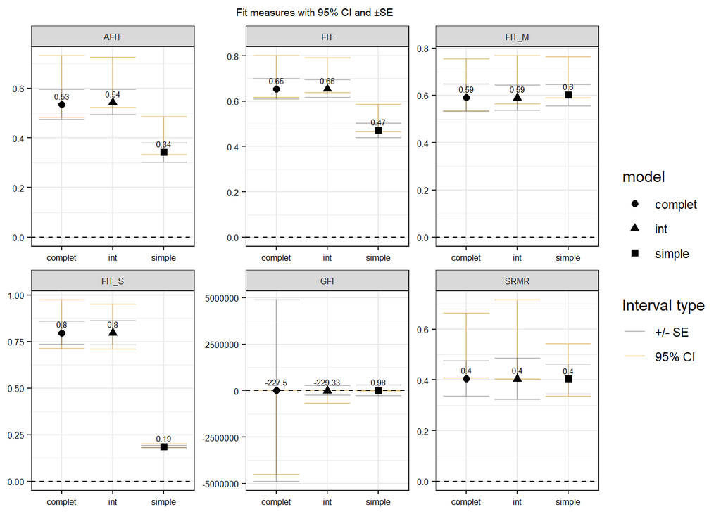

```r
ggplot(fit, aes(x = model, y = Estimate)) +
    geom_errorbar(aes(ymin = CI_LB, ymax = CI_UB, color = "95% CI"),
                   height = 0.1, alpha = 0.4) +
    geom_errorbar(aes(ymin = Estimate - Std.Error,
                       ymax = Estimate + Std.Error,
                       color = "+/- SE"),
                   height = 0.1, linewidth = 0.4, alpha = 0.4) +
    geom_point(aes(shape = model), size = 2) +
    geom_text(aes(label = round(Estimate, 2)), size = 2, vjust = -0.86)+
    geom_hline(yintercept = 0, linetype = "dashed") +
    facet_wrap(~ Measure, scales = "free")+
    theme_bw() +
    labs(title = "Fit measures with 95% CI and ±SE")+
    theme(axis.text = element_text(color = "black", size = 6),
          axis.title = element_blank(),
          plot.title = element_text(hjust = 0.5, size = 7),
          strip.text = element_text(size = 6))+
  scale_color_manual(name = "Interval type",
                     values = c(
                       "95% CI" = "orange3",
                       "+/- SE" = "grey40"))
```

### 3.1.7 scatterplot VL

```r
# str(mod_int$WR)
# str(mod_int$MatW)

sum_gsca_int$weights
```

```
##    group                          term estimate std.error   ci_lb  ci_ub
## 1    all                AMR_ville_FQ_R   1.0000    0.0000  1.0000 1.0000
## 2    all                 log_AMC_ES_FQ   0.4729    0.2239 -0.0092 0.9212
## 3    all              log_AMC_ville_FQ   0.5984    0.2081  0.0825 0.9856
## 4    all    AMR_animaux_compagnie_FQ_R   0.3728    0.3670 -0.5559 0.6827
## 5    all   AMR_animaux_production_FQ_R  -0.0587    0.2973 -0.5810 0.5865
## 6    all                    veto_by_AC   0.1261    0.2652 -0.4852 0.4350
## 7    all log_UGB_density_livestock_tot  -0.7796    0.6665 -0.9279 1.2262
## 8    all                  air_PM25_pop   0.6524    0.5967 -0.8905 0.9539
## 9    all                    dju_refroi   0.7292    0.6527 -0.9283 0.9864
## 10   all                        EQI_st  -0.6000    0.5813 -0.8978 0.9734
## 11   all                   medecin_hab   0.6620    0.6654 -0.9758 0.9452
```

```r
dimnames(mod_int$WR)
```

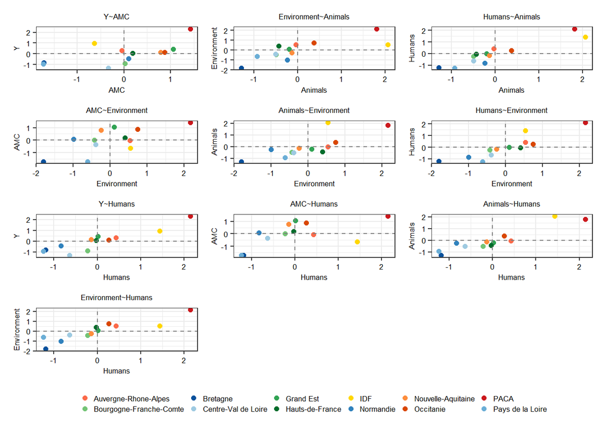

```r
rownames(mod_int$WR) <- sum_gsca_int$weights$term
colnames(mod_int$WR) <- c("Y", "AMC", "Animals",
                          "Environment", "Humans")

indicateur <- rownames(mod_int$WR)
X <- scale(dfPC1.AMR_ville_FQ[, indicateur])
latent_coord <- X %*% mod_int$WR

# 1. Transformer la matrice en data frame avec une colonne "id" pour la couleur
df_coord <- as.data.frame(latent_coord) %>%
  rownames_to_column("id")

# 2. Récupérer les termes
terms <- sum_gsca_int$paths$term

# 3. Fonction qui génère un scatterplot pour un terme donné "Y~AMC"
make_scatter <- function(term) {
  vars <- str_split(term, "~")[[1]]
  yvar <- vars[1]
  xvar <- vars[2]

  ggplot(df_coord, aes(x = .data[[xvar]], y = .data[[yvar]], col = id)) +
    geom_point(size = 1.6) +
    theme_bw() +
    geom_hline(yintercept = 0, col = "grey50", linetype = "dashed") +
    geom_vline(xintercept = 0, col = "grey50", linetype = "dashed") +
    theme(legend.title = element_blank(),
          axis.text = element_text(color = "black", size = 6.5),
          axis.title = element_text(size = 6.5),
          legend.text = element_text(size = 6.5),
          plot.title = element_text(hjust = 0.5, size = 6.5),
        legend.position = "bottom",
        legend.spacing = unit(0.5, "cm"),
        legend.key.height = unit(0.1, "cm"),
        legend.key.width = unit(0.1, "cm"),
        legend.key.spacing.y = unit(0.1, "cm")) +
    scale_color_manual(values = cols) +
    labs(title = term, x = xvar, y = yvar)
}

# 4. Appliquer à tous les termes -> liste de ggplots nommée
plot_list <- map(terms, make_scatter) %>%
  set_names(terms)

wrap_plots(plot_list, ncol = 3) +
  plot_layout(guides = "collect") &
  theme(legend.position = "bottom") &
  guides(col = guide_legend(nrow = 2, override.aes = list(size = 1.6)))
```

```r
# ggsave("C:/Users/g.martet/Documents/functional_study/figures diapo/scatterplot_VL_AMR_ville_FQ.png", width = 7, height = 7)
```